# Essential Play

Dave Gurnell and Noel Welsh

Version 1.0, April 2015

# Introduction

*Essential Play* is aimed at beginner-to-intermediate Scala developers who want to get started using the [Play 2](http://playframework.com) web framework. The material presented focuses on Play version 2.3, although the approaches introduced are generally applicable to Play 2.2+.

By the end of the course we will have a solid foundation in each of the main libraries Play provides for building sites and services:

- Routing, controllers, and actions
- Manipulating requests and responses
- Generating HTML
- Parsing and validating form data
- Reading and writing JSON
- Asynchronous request handling
- Calling external web services

Many thanks to [Richard Dallaway](http://twitter.com/d6y), [Jonathan Ferguson](http://twitter.com/jonoabroad), and the team at [Underscore](http://underscore.io) for their invaluable contributions and extensive proof reading.

## Conventions Used in This Book

This book contains a lot of technical information and program code. We use the following typographical conventions to reduce ambiguity and highlight important concepts:

### Typographical Conventions

New terms and phrases are introduced in *italics*. After their initial introduction they are written in normal roman font.

Terms from program code, filenames, and file contents, are written in `monospace font`. Note that we do not distinguish between singular and plural forms. For example, might write `String` or `Strings` to refer to the `java.util.String` class or objects of that type.

References to external resources are written as [hyperlinks](http://underscore.io). References to API documentation are written using a combination of hyperlinks and monospace font, for example: [`scala.Option`](http://www.scala-lang.org/api/2.11.2/#scala.Option).

### Source Code

Source code blocks are written as follows. Syntax is highlighted appropriately where applicable:

```scala
object MyApp extends App {
  println("Hello world!") // Print a fine message to the user!
}
```

Some lines of program code are too wide to fit on the page. In these cases we use a *continuation character* (curly arrow) to indicate that longer code should all be written on one line. For example, the following code:

```scala
println("This code should all be written ↩
  on one line.")
```

should actually be written as follows:

```scala
println("This code should all be written on one line.")
```

### Callout Boxes

We use three types of *callout box* to highlight particular content:

Tip callouts indicate handy summaries, recipes, or best practices.

Advanced callouts provide additional information on corner cases or underlying mechanisms. Feel free to skip these on your first read-through—come back to them later for extra information.

Warning callouts indicate common pitfalls and gotchas. Make sure you read these to avoid problems, and come back to them if you’re having trouble getting your code to run.

# 1 Getting Started

In this chapter we will discuss how to get started with Play. Our main focus will be on building and running the exercises in this book, but we will also discuss installing and using *SBT*, the Scala Build System, to compile, test, run, and deploy Play projects.

## 1.1 Installing the Exercises

The exercises and sample code in this book are all packaged with a copy of SBT. All you need to get started are Git, a Java runtime, and an Internet connection to download other dependencies.

Start by cloning the Github repository for the exercises:

```bash
bash$ git clone https://github.com/underscoreio/essential-play-code.git

bash$ cd essential-play-code

dave@Jade ~/d/p/essential-play-code> git status
# On branch exercises...

bash$ ls -1
chapter1-hello
chapter2-calc
chapter2-chat
# And so on...
```

The repository has two branches, `exercises` and `solutions`, each containing a set of self-contained Play projects in separate directories. We have included one exercise to serve as an introduction to SBT. Change to the `chapter1-hello` directory and start SBT using the shell script provided:

```bash
bash$ cd chapter1-hello

bash$ ./sbt.sh
# Lots of output here...
# The first run will take a while...

[app] $
```

*“Downloading the Internet”*

The first commands you run in SBT will cause it to download various dependencies, including libraries for Play, the Scala runtime, and even the Scala compiler. This process can take a while and is affectionately known to Scala developers as “downloading the Internet”.

These files are only downloaded once, after which SBT caches them on your system. Be prepared for delays of up to a few minutes:

- the first time you start SBT;
- the first time you compile your code;
- the first time you compile your unit tests.

Things will speed up considerably once these files are cached.

Once SBT is initialised, your prompt should change to `[app] $`, which is the name of the Play project we’ve set up for you. You are now interacting with SBT. Compile the project using the `compile` command to check everything is working:

```bash
[app] $ compile
# Lots of output here...
# The first run will take a while...
[info] Updating {file:/Users/dave/dev/projects/essential-play-code/}app...
[info] Resolving jline#jline;2.12 ...
[info] Done updating.
[info] Compiling 3 Scala sources and 1 Java source to ↩
       /Users/dave/dev/projects/essential-play-code/ ↩
       target/scala-2.11/classes...
[success] Total time: 7 s, completed 13-Jan-2015 11:15:39

[app] $
```

If the project compiles successfully, try running it. Enter `run` to start a development web server and access it at http://localhost:9000 to test out the app:

```bash
[app] $ run

--- (Running the application from SBT, auto-reloading is enabled) ---

[info] play - Listening for HTTP on /0:0:0:0:0:0:0:0:9000

(Server started, use Ctrl+D to stop and go back to the console...)

# Play waits until we open a web browser...
[info] play - Application started (Dev)
```

If everything worked correctly you should see the message `"Hello world!"` in your browser. Congratulations—you have run your first Play web application!

### 1.1.1 Other Exercises in this Book

The process you have used here is the same for each exercise in this book:

1. change to the relevant exercise directory;
2. start SBT;
3. issue the relevant SBT commands to compile and run your code.

You will find instructions for each exercise in the text of the book. Also look out for comments like the following in the exercise source code:

```scala
// TODO: Complete this bit!
```

These tell you where you need to modify the code to complete the exercises. There are complete solutions to each exercise in the `solutions` branch of the repository.

*Getting Help*

Resist the temptation to look at the solutions if you get stuck! You *will* make mistakes when you first start programming Play applications, but mistakes are the best way to teach yourself.

If you do get stuck, join our Gitter chat room to get help from the authors and other students.

Try to get the information you need to solve the immediate problem without gaining complete access to the solution code. You’ll proceed slower this way but you’ll learn a lot faster and the knowledge will stick with you longer.

## 1.2 Installing SBT

As we discussed in the previous section, each exercise and solution is bundled with its own scripts and binaries for SBT. This is a great setup for this book, but after you’ve finished the exercises you will want to install SBT properly so you can work on your own applications. In this section we will discuss the options available to you to do this.

### 1.2.1 How Does SBT Work?

SBT relies heavily on account-wide caches to store project dependencies. By default these caches are located in two folders:

- `~/.sbt` contains configuration files and account-wide SBT plugins; and
- `~/.ivy2` contains cached library dependencies (similar to `~/.m2` for Maven).

SBT downloads dependencies on demand and caches them for future use in `~/.ivy2`. In fact, the JAR we run to boot SBT is actually a *launcher* (typically named `sbt-launch.jar`) that downloads and caches the correct versions of SBT and Scala needed for our project.

This means we can use a single launcher to compile and run projects with different version requirements for libraries, SBT, and Scala. We are can use separate launchers for each project, or a single launcher that covers all projects on our development machine. The shared caches allow multiple SBT launchers to work indepdently without conflict.

Despite the convenience of these account-wide caches, they have two important drawbacks to be aware of:

1. the first time we build a project we must be connected to the Internet for SBT to download the required dependencies; and
2. as we saw in the previous section, the first build of a project may take a long time.

### 1.2.2 Flavours of SBT

SBT is available from a number of sources under a variety of different names. Here are the main options available, any of which is a suitable starting point for your own applications:

- **System-wide vanilla SBT**—We can install a system-wide SBT launcher using the instructions on the SBT web site. Linux and OS X users can download copies via package managers such as Apt, MacPorts, and Homebrew.
- **Project-local vanilla SBT**—We can bundle the SBT launcher JAR with a project and create shell scripts to start it with the correct command line arguments. This is the approach used in the exercises and solutions for this book. ZIP downloads of the required files are available from the SBT web site.
- **Typesafe Activator**—Activator, available from Typesafe’s web site, is a tool for getting started with the Typesafe Stack. The `activator` command is actually just an alias for SBT, although the activator distribution comes pre-bundled with a global plugin for generating new projects from templates (the `activator new` command).
- **“SBT Extras” script**—Paul Philips released an excellent shell script that acts as a front-end for SBT. The script does the bootstrapping process of detecting Scala and SBT versions without requiring a launcher JAR. Linux and OS X users can download the script from Paul’s Github page.

*Legacy Play Distributions*

Older downloads from http://playframework.com shipped with a built-in `play` command that was also an alias for SBT. However, the old Play distributions configured SBT with non-standard cache directories that meant it did not play nicely with other installs.

We recommend replacing any copies of the legacy `play` command with one of the other options described above. Newer versions of Play are shipped with Activator, which interoperates well with other locally installed copies of SBT.

## 1.3 Using SBT

At the beginning of this chapter we cloned the Git repository of the exercises for this book and ran our first SBT commands on the `chapter1-hello` sample project. Let’s revisit this project to investigate the standard SBT commands for compiling, running, and deploying Play applications.

Change to the `chapter1-hello` directory if you are not already there and start SBT using the shell script provided:

```bash
bash$ cd essential-play-code/chapter1-hello

bash$ ./sbt.sh

[app] $
```

*SBT with and without Play*

Play is distributed in two components:

- a set of libraries used by our web applications at runtime;
- an *SBT plugin* that customises the default behaviour of SBT, adding and altering commands to help us build applications for the web.

This section covers the behaviour of SBT *with the Play plugin activated*. We have included callout boxes like this one to highlight the differences from vanilla SBT.

### 1.3.1 Interative and Batch Modes

We can start SBT in two modes: *interactive mode* and *batch mode*. Batch mode is useful for continuous integration and delivery, while interactive mode is faster and more convenient for use in development. Most of our time in this book will be spent in interactive mode.

We start interactive mode be running SBT with no command line arguments. SBT displays a command prompt where we can enter commands such as `compile`, `run`, and `clean` to build our code. Pressing `Ctrl+D` quits SBT when we’re done:

```bash
bash$ ./sbt.sh

[app] $ compile
# SBT compiles our code and we end up back in SBT...

[app] $ ^D
# Ctrl+D quits back to the OS command prompt

bash$
```

We start SBT in batch mode by issuing commands as arguments on the OS command line. SBT executes the commands immediately and then exits back to the OS. The commands—`compile`, `run`, `clean` and so on—are the same in both modes:

```bash
bash$ ./sbt.sh compile
# SBT compiles our code and we end up back on the OS command prompt...

bash$
```

*The SBT command prompt*

The default SBT command prompt is a single echelon:

```bash
>
```

Play changes this to the name of the project surrounded by square brackets:

```bash
[app] $
```

You will find the prompt changing as you switch back and forth between Play projects and vanilla Scala projects.

*Directory structure of non-Play projects*

By default SBT uses two directories to store application and test code:

- `src/main/scala`—Scala application code;
- `src/test/scala`—Scala unit tests.

Play replaces these with the `app`, `app/assets`, `views`, `public`, `conf`, and `test` directories, providing locations for the extra files required to build a web application.

### 1.3.2 Common SBT Commands

The following table contains a summary of the most useful SBT commands for working with Play. Each command is covered in more detail below.

Many commands have dependencies listed in the right-hand column. For example, `compile` depends on `update`, `run` depends on `compile`, and so on. When we run a command SBT automatically runs its dependencies as well. For example, whwnever we run the `compile` command, SBT will run `update` for us automatically.

| SBT Command | Purpose | Notes and Dependencies |
| --- | --- | --- |
| `update` | Resolves and caches library dependencies | No dependencies |
| `compile` | Compiles application code, including code under `app`, `app/assets`, and `views` | Depends on `update` |
| `run` | Runs application in development mode, continuously recompiles on demand | Depends on `compile` |
| `console` | Starts an interactive Scala prompt | Depends on `compile` |
| `test:compile` | Compiles all unit tests | Depends on `compile` |
| `test` | Compiles and runs all unit tests | Depends on `test:compile` |
| `testOnly foo.Bar` | Compiles and runs unit tests defined in the class `foo.Bar` | Depends on `test:compile` |
| `stage` | Gathers all dependencies into a single stand-alone directory | Depends on `compile` |
| `dist` | Gathers staged files into a ZIP file | Depends on `stage` |
| `clean` | Deletes temporary build files under `${projecthome}/target` | No dependencies |
| `eclipse` | Generates Eclipse project files | No dependencies, requires the sbteclipse plugin |

### 1.3.3 Compiling and Cleaning Code

The `compile` and `test:compile` commands compile our application and unit tests respectively. The `clean` command deletes the generated class files in case we want to rebuild from scratch (`clean` is not normally required as we shall see below).

Let’s clean the example project from the previous section and recompile the code as an example:

```scala
bash$ ./sbt.sh
[info] Loading project definition from ↩
       /Users/dave/dev/projects/essential-play-code/project
[info] Set current project to app (in build file:/.../essential-play-code/)

[app] $ clean
[success] Total time: 0 s, completed 13-Jan-2015 11:15:32

[app] $ compile
[info] Updating {file:/Users/dave/dev/projects/essential-play-code/}app...
[info] Resolving jline#jline;2.12 ...
[info] Done updating.
[info] Compiling 3 Scala sources and 1 Java source to ↩
       /Users/dave/dev/projects/essential-play-code/ ↩
       target/scala-2.11/classes...
[success] Total time: 7 s, completed 13-Jan-2015 11:15:39

[app] $
```

In the output from `compile` SBT tells us how many source files it compiled and how long compilation took—7 seconds in this case! Fortunately we normally don’t need to wait this long. The `compile` and `test:compile` commands are *incremental*—they automatically recompile only the files that have changed since the last time we compiled the code. We can see the effect of incremental compilation by changing our application and running `compile` again. Open `app/controllers/AppController.scala` in an editor and change the `"Hello World!"` line to greet you by name:

```scala
package controllers

import play.api.Logger
import play.api.Play.current
import play.api.mvc._

import models._

object AppController extends Controller {
  def index = Action { request =>
    Ok("Hello Dave!")
  }
}
```

Now re-run the `compile` command:

```bash
[app] $ compile
[info] Compiling 1 Scala source to ↩
       /Users/dave/dev/projects/essential-play-code/ ↩
       target/scala-2.11/classes...
[success] Total time: 1 s, completed 13-Jan-2015 12:26:16

[app] $
```

One Scala file compiled in one second. Much better! Incremental compilation means we can rely on `compile` and `test:compile` to do the right thing to recompile our code—we rarely need to use `clean` to rebuild from scratch.

*Compiling in interactive mode*

Another reason our first `compile` command was slow was because SBT spent a lot of time loading the Scala compiler for the first time. If we keep SBT open in interactive mode, subsequent `compile` commands become much faster.

### 1.3.4 Watch Mode

We can prefix any SBT command with a `~` to run the command in *watch mode*. SBT watches our codebase and reruns the specified task whenever we change a source file. Type `~compile` at the prompt to see this in action:

```bash
[app] $ ~compile
[success] Total time: 0 s, completed 13-Jan-2015 12:31:09
1. Waiting for source changes... (press enter to interrupt)
```

SBT tells us it is “waiting for source changes”. Whenever we edit a source file it will trigger the `compile` task and incrementally recompile the changed code. Let’s see this by introducing a compilation error to `AppController.scala`. Open the source file again and delete the closing `"` from `"Hello Name!"`. As soon as we save the file we see the following in SBT:

```bash
[info] Compiling 1 Scala source to ↩
       /Users/dave/dev/projects/essential-play-code/ ↩
       target/scala-2.11/classes...
[error] /Users/dave/dev/projects/essential-play-code/app/ ↩
        controllers/AppController.scala:11: unclosed string literal
[error]     Ok("Hello Dave!)
[error]        ^
[error] /Users/dave/dev/projects/essential-play-code/app/ ↩
        controllers/AppController.scala:12: ')' expected but '}' found.
[error]   }
[error]   ^
[error] two errors found
[error] (compile:compile) Compilation failed
[error] Total time: 0 s, completed 13-Jan-2015 12:32:45
2. Waiting for source changes... (press enter to interrupt)
```

The compiler has picked up the error and produced some error messages as a result. If we fix the error again and save the file, the error messages disappear:

```bash
[success] Total time: 0 s, completed 13-Jan-2015 12:33:55
3. Waiting for source changes... (press enter to interrupt)
```

Watch mode is extremely useful for getting instant feedback during development. Simply press *Enter* when you’re done to return to the SBT command prompt.

*Watch mode and other tasks*

We can use watch mode with *any* SBT command. For example:

- `~compile` watches our code and recompiles it whenever we change a file;
- `~test` watches our code and reruns the unit tests whenever we change a file; and
- `~dist` watches our code and builds a new distributable ZIP archive whenever we change a file.

This behaviour is built into SBT and works irrespective of whether we’re using Play.

### 1.3.5 Running a Development Web Server

We can use the `run` command to run our application in a development environment. This command starts a development web server, watches for incoming connections, and recompiles our code whenever an incoming request is received.

Let’s see this in action. First `clean` the codebase, then enter `run` at the SBT prompt:

```bash
[app] $ clean
[success] Total time: 0 s, completed 13-Jan-2015 12:44:07
[app] $ run
[info] Updating {file:/Users/dave/dev/projects/essential-play-code/}app...
[info] Resolving jline#jline;2.12 ...
[info] Done updating.

--- (Running the application from SBT, auto-reloading is enabled) ---

[info] play - Listening for HTTP on /0:0:0:0:0:0:0:0:9000

(Server started, use Ctrl+D to stop and go back to the console...)
```

SBT starts up a web server on `/0:0:0:0:0:0:0:0:9000` (which means `localhost:9000` in IPv6-speak) and waits for a browser to connect. Open up `http://localhost:9000` in a web browser and watch the SBT console to see what happens. Play receives the incoming request and recompiles and runs the application to respond:

```bash
[info] Compiling 3 Scala sources and 1 Java source to ↩
       /Users/dave/dev/projects/essential-play-code/ ↩
       target/scala-2.11/classes...
[info] play - Application started (Dev)
```

If we reload the web page without changing any source code, Play simply serves up the response again. However, if we edit the code and reload the page, Play recompiles the application before responding.

*Differences between `run` and watch mode*

The `run` command is a great way to get instant feedback when developing an application. However, we have to send a request to the web browser to get Play to recompile the code. In contrast, watch mode recompiles the application as soon as we change a file.

Sometimes using `~compile` or `~test` can be a more efficient way of working. It depends on how much code we’re rewriting and how many compile errors we are likely to introduce during coding.

*Running non-Play applications*

SBT’s default `run` command is much simpler than the command provided by Play. It simply runs a command line or graphical application and exits when it terminates. Play provides the development web server and continuous compilation functionality.

#### 1.3.5.1 Running Unit Tests

The `test` and `testOnly` commands are used to run unit tests. `test` runs all unit tests for the application; `testOnly` runs a single test suite. Let’s use `test` to test our sample application:

```bash
[app] $ test
[info] Compiling 1 Scala source to ↩
       /Users/dave/dev/projects/essential-play-code/ ↩
       target/scala-2.10/test-classes...
[info] ApplicationSpec:
[info] AppController
[info] - must respond with a friendly message
[info] ScalaTest
[info] Run completed in 934 milliseconds.
[info] Total number of tests run: 1
[info] Suites: completed 1, aborted 0
[info] Tests: succeeded 1, failed 0, canceled 0, ignored 0, pending 0
[info] All tests passed.
[info] Passed: Total 1, Failed 0, Errors 0, Passed 1
[success] Total time: 2 s, completed 14-Jan-2015 14:02:45

[app] $
```

We don’t have many tests for our sample application so testing is fast. If we had lots of test suites we could focus on a single suite using the `testOnly` command. `testOnly` takes the fully qualified class name of the desired suite as an argument:

```bash
[app] $ testOnly controllers.AppControllerSpec
[info] ScalaTest
[info] Run completed in 44 milliseconds.
[info] Total number of tests run: 0
[info] Suites: completed 0, aborted 0
[info] Tests: succeeded 0, failed 0, canceled 0, ignored 0, pending 0
[info] No tests were executed.
[info] Passed: Total 0, Failed 0, Errors 0, Passed 0
[info] No tests to run for test:testOnly
[success] Total time: 1 s, completed 14-Jan-2015 14:06:42

[app] $
```

As with `compile`, both of these commands can run in watch mode by prefixing them with a `~`. Whenever we change and save a file, SBT will recompile it and rerun our tests for us.

### 1.3.6 Packaging and Deploying the Application

The `stage` command bundles the compiled application and all of its dependencies into a single directory under the directory `target/universal/stage`. Let’s see this in action:

```bash
[app] $ stage
[info] Packaging /Users/dave/dev/projects/essential-play-code/ ↩
       target/scala-2.10/app_2.10-0.1-SNAPSHOT-sources.jar ...
[info] Done packaging.
[info] Packaging /Users/dave/dev/projects/essential-play-code/ ↩
       target/scala-2.10/app_2.10-0.1-SNAPSHOT.jar ...
[info] Main Scala API documentation to /Users/dave/dev/projects/ ↩
       essential-play-code/target/scala-2.10/api...
[info] Done packaging.
[info] Wrote /Users/dave/dev/projects/essential-play-code/ ↩
       target/scala-2.10/app_2.10-0.1-SNAPSHOT.pom
[info] Packaging /Users/dave/dev/projects/essential-play-code/ ↩
       target/app-0.1-SNAPSHOT-assets.jar ...
[info] Done packaging.
model contains 10 documentable templates
[info] Main Scala API documentation successful.
[info] Packaging /Users/dave/dev/projects/essential-play-code/ ↩
       target/scala-2.10/app_2.10-0.1-SNAPSHOT-javadoc.jar ...
[info] Done packaging.
[success] Total time: 1 s, completed 14-Jan-2015 14:08:14

[app] $
```

Now press `Ctrl+D` to quit SBT and take a look at the package created by the `stage` command:

```bash
bash$ ls -l target/universal/stage/
total 0
drwxr-xr-x   4 dave  staff   136 14 Jan 14:11 bin
drwxr-xr-x   3 dave  staff   102 14 Jan 14:11 conf
drwxr-xr-x  44 dave  staff  1496 14 Jan 14:11 lib
drwxr-xr-x   3 dave  staff   102 14 Jan 14:08 share

bash$ ls -l target/universal/stage/bin
total 40
-rwxr--r--  1 dave  staff  12210 14 Jan 14:11 app
-rw-r--r--  1 dave  staff   6823 14 Jan 14:11 app.bat
```

SBT has created a directory `target/universal/stage` containing all the dependencies we need to run the application. It has also created two executable scripts under `target/universal/stage/bin` to set an appropriate classpath and run the application from the command prompt. If we run one of these scripts, the app starts up and allows us to connect as usual:

```bash
bash$ target/universal/stage/bin/app
Play server process ID is 22594
[info] play - Application started (Prod)
[info] play - Listening for HTTP on /0:0:0:0:0:0:0:0:9000
```

The contents of `target/universal/stage` can be copied onto a remote web server and run as a standalone application. We can use standard Unix commands such as `rsync` and `scp` to achieve this. Sometimes, however, it is more convenient to have an archive to distribute. We can use the `dist` command to create a ZIP of `target/universal/stage` for easy distribution:

```bash
[app] $ dist
[info] Wrote /Users/dave/dev/projects/essential-play-code/ ↩
       target/scala-2.10/app_2.10-0.1-SNAPSHOT.pom
[info]
[info] Your package is ready in /Users/dave/dev/projects/ ↩
       essential-play-code/target/universal/app-0.1-SNAPSHOT.zip
[info]
[success] Total time: 2 s, completed 14-Jan-2015 14:15:50
```

*Packaging non-Play applications*

The `stage` and `dist` commands are specific to the Play plugin. SBT contains a built-in `package` command for building non-Play projects, but this functionality is beyond the scope of this book.

### 1.3.7 Working With Eclipse

The sample SBT project includes a plugin called sbteclipse that generates project files for Eclipse. Run the `eclipse` command to see this in action:

```bash
[app] $ eclipse
[info] About to create Eclipse project files for your project(s).
[info] Successfully created Eclipse project files for project(s):
[info] app

[app] $
```

Now start Eclipse and import your SBT project using *File menu > Import… > General > Existing files into workspace* and select the root directory of the project source tree in the *Select root directory* field. Click *Finish* to add a project called `app` to the Eclipse workspace.

### 1.3.8 Working With Intellij IDEA

Newer versions of the Scala plugin for Intellij IDEA support direct import of SBT projects from within the IDE. Choose *File menu > Import… > SBT* and select the root directory of the project source tree. The import wizard will do the rest automatically.

### 1.3.9 Configuring SBT

A full discussion of how to write SBT project configurations is beyond the scope of this book. For more information we recommend reading the tutorial on the SBT web site and the build documentation on the Play web site. The sample projects and exercises for this book will provide a good starting point for your own projects.

# 2 The Basics

In this chapter we will introduce five fundamental concepts used to process web requests in Play: *actions*, *controllers*, *routes*, *requests*, and *results*. With these concepts we will be able to read incoming HTTP requests, pass them to the correct module of the application code, extract appropriate information, and send a response back to the client.

## 2.1 Directory Structure

Play projects use the following directory structure, which is quite different to the standard structure of an SBT project:

```bash
root/
 +- app/        # Scala application code
 |   |
 |   +- assets/ # client assets for compilation by SBT
 |              # (Javascript, Coffeescript, Less CSS, and so on)
 |
 +- views/      # Twirl templates for compilation by SBT
 |
 +- public/     # static assets to be served by the application
 |              # (HTML, Javascript, CSS, and so on)
 |
 +- conf/       # runtime configuration files bundled with the
 |              # deployed application (route config, logs, DB config)
 |
 +- test/       # Scala unit tests
 |
 +- logs/       # logs generated by the development server
 |
 +- project/    # configuration files and temporary files
 |
 +- target/     # temporary directory used to store completed builds
```

Most of our time in this book will be spent editing Scala files in the `app` and `test` directories and the `routes` configuration file in the `conf` directory. You can find out more about the asset directories and configuration files in the Play documentation.

## 2.2 Actions, Controllers, and Routes

We create Play web applications from *actions*, *controllers*, and *routes*. In this section we will see what each part does and how to wire them together.

### 2.2.1 Hello, World!

*Actions* are objects that handle web requests. They have an `apply` method that accepts a [`play.api.mvc.Request`](https://www.playframework.com/documentation/2.3.x/api/scala/index.html#play.api.mvc.Request) and returns a [`play.api.mvc.Result`](https://www.playframework.com/documentation/2.3.x/api/scala/index.html#play.api.mvc.Result). We create them using one of several `apply` methods on the [`play.api.mvc.Action`](https://www.playframework.com/documentation/2.3.x/api/scala/index.html#play.api.mvc.Action) companion:

```scala
import play.api.mvc.Action

Action { request =>
  Ok("Hello, world!")
}
```

We package actions inside `Controllers`. These are singleton objects that contain action-producing methods:

```scala
package controllers

import play.api.mvc.{ Action, Controller }

object HelloController extends Controller {
  def hello = Action { request =>
    Ok("Hello, world!")
  }

  def helloTo(name: String) = Action { request =>
    Ok(s"Hello, $name!")
  }
}
```

We use *routes* to dispatch incoming requests to `Actions`. Routes choose `Actions` based on the *HTTP method* and *path* of the request. We write routes in a Play-specific DSL that is compiled to Scala by SBT:

```bash
GET /      controllers.HelloController.hello
GET /:name controllers.HelloController.helloTo(name: String)
```

We’ll learn more about this DSL in the next section. By convention we place controllers in the `controllers` package in the `app/controllers` folder, and routes in a `conf/routes` configuration file.

The structure of our minimal Play application is as follows:

```
root/
 +- app/
 |   +- controllers/
 |       +- HelloController.scala # Controller and actions (Scala code)
 +- conf/
 |   +- routes                    # Routes (Play routing DSL)
 +- project/
 |   +- plugins.sbt               # Load the Play plugin (SBT code)
 +- build.sbt                     # Configure the build (SBT code)
```

### 2.2.2 The Anatomy of a Controller

Let’s take a closer look at the controller in the example above. The code in use comes from two places:

- the [`play.api.mvc`](https://www.playframework.com/documentation/2.3.x/api/scala/index.html#play.api.mvc.package) package;
- the [`play.api.mvc.Controller`](https://www.playframework.com/documentation/2.3.x/api/scala/index.html#play.api.mvc.Controller) trait (via inheritance).

The controller, called `HelloController`, is a subtype of [`play.api.mvc.Controller`](https://www.playframework.com/documentation/2.3.x/api/scala/index.html#play.api.mvc.Controller). It defines two `Action`-producing methods, `hello` and `helloTo`. Our routes specify which of these methods to call when a request comes in.

Note that `Actions` and `Controllers` have different lifetimes. `Controllers` are created when our application boots and persist until it shuts down. `Actions` are created and executed in response to incoming `Requests` and have a much shorter lifespan. Play passes parameters from our routes to *the method that creates the `Action`*, not to the action itself.

Each of the example `Actions` creates an `Ok` response containing a simple message. `Ok` is a helper object inherited from `Controller`. It has an `apply` method that creates `Results` with HTTP status 200. The actual return type of `Ok.apply` is [`play.api.mvc.Result`](https://www.playframework.com/documentation/2.3.x/api/scala/index.html#play.api.mvc.Result).

Play uses the type of the argument to `Ok.apply` to determine the `Content-Type` of the `Result`. The `String` arguments in the example create a `Results` of type `text/plain`. Later on we’ll see how to customise this behaviour and create results of different types.

### 2.2.3 Take Home Points

The backbone of a Play web application is made up of `Actions`, `Controllers`, and routes:

- [`Actions`](https://www.playframework.com/documentation/2.3.x/api/scala/index.html#play.api.mvc.Action) are functions from [`Requests`](https://www.playframework.com/documentation/2.3.x/api/scala/index.html#play.api.mvc.Request) to [`Results`](https://www.playframework.com/documentation/2.3.x/api/scala/index.html#play.api.mvc.Result);
- [`Controllers`](https://www.playframework.com/documentation/2.3.x/api/scala/index.html#play.api.mvc.Controller) are collections of action-producing methods;
- Routes map incoming `Requests` to `Action`-producing method calls on our `Controllers`.

We typically place controllers in a `Controllers` package in the `app/controllers` folder. Routes go in the `conf/routes` file (no filename extension).

In the next section we will take a closer look at routes.

### 2.2.4 Exercise: Time is of the Essence

The `chapter2-time` directory in the exercises contains an unfinished Play application for telling the time.

Complete this application by filling in the missing actions and routes. Implement the three missing actions described in the comments in `app/controllers/TimeController.scala` and complete the `conf/routes` file to hook up the specified URLs.

We’ve written this project using the Joda Time library to handle time formatting and time zone conversion. Don’t worry if you haven’t used the library before—the `TimeHelpers` trait in `TimeController.scala` contains all of the functionality needed to complete the task at hand.

Test your code using `curl` if you’re using Linux or OS X or a browser if you’re using Windows:

```bash
bash$ curl -v 'http://localhost:9000/time'
# HTTP headers...
4:18 PM

bash$ curl -v 'http://localhost:9000/time/zones'
# HTTP headers...
Africa/Abidjan
Africa/Accra
Africa/Addis_Ababa
# etc...

bash$ curl -v 'http://localhost:9000/time/CET'
# HTTP headers...
5:21 PM

bash$
```

*Be agile!*

Complete the exercises by coding small units of end-to-end functionality. Start by implementing the simplest possible action that you can test on the command line:

```scala
// Action:
def time = Action { request =>
  Ok("TODO: Complete")
}

// Route:
GET /time controllers.TimeController.time
```

Write the route for this action and test it using `curl` before you move on. The faster you get to running your code, the faster you will learn from any mistakes.

Answer the following questions when you’re done:

1. What happens when you connect to the application using the following URL? Why does this not work as expected and how can you work around the behaviour?

   ```bash
   bash$ curl -v 'http://localhost:9000/time/Africa/Abidjan'
   ```

2. What happens when you send a `POST` request to the application?

   ```bash
   bash$ curl -v -X POST 'http://localhost:9000/time'`
   ```

The main task in the actions in `TimeController.scala` is to convert the output of the various methods in `TimeHelpers` to a `String` so we can wrap it in an `Ok()` response:

```scala
def time = Action { request =>
  Ok(timeToString(localTime))
}

def timeIn(zoneId: String) = Action { request =>
  val time = localTimeInZone(zoneId)
  Ok(time map timeToString getOrElse "Time zone not recognized.")
}

def zones = Action { request =>
  Ok(zoneIds mkString "\n")
}
```

Hooking up the routes would be straightforward, except we included one gotcha to trip you up. You must place the route for `TimeController.zones` *above* the route for `TimeController.timeIn`:

```bash
GET /time        controllers.TimeController.time
GET /time/zones  controllers.TimeController.zones
GET /time/:zone  controllers.TimeController.timeIn(zone: String)
```

If you put these two in the wrong order, Play will treat the word `zones` in `/time/zones` as the name of a time zone and route the request to `TimeController.timeIn("zones")` instead of `TimeController.zones`.

The answers to the questions are as follows:

1. The mistake here is that we haven’t escaped the `/` in `Africa/Abidjan`. Play interprets this as a path with three segments but our route will only match two. The result is a 404 response.

   If we encode the value as `Africa%2FAbidjan` the application will respond as desired. The `%2F` is decoded by Play before the argument is passed to `timeIn`:

   ```bash
   bash$ curl 'http://localhost:9000/time/Africa%2FAbidjan'
   4:38 PM
   ```

2. Our routes are only configured to match incoming `GET` requests so `POST` requests result in a 404 response.

## 2.3 Routes in Depth

The previous section introduced `Actions`, `Controllers`, and routes. `Actions` and `Controllers` are standard Scala code, but routes are something new and specific to Play.

We define Play routes using a special DSL that compiles to Scala code. The DSL provides both a convenient way of mapping URIs to method calls and a way of mapping method calls *back* to URIs. In this section we will take a deeper look at Play’s routing DSL including the various ways we can extract parameters from URIs.

### 2.3.1 Path Parameters

Routes associate *URI patterns* with *action-producing method calls*. We can specify *parameters* to extract from the URI and pass to our controllers. Here are some examples:

```
# Fixed route (no parameters):
GET /hello controllers.HelloController.hello

# Single parameter:
GET /hello/:name controllers.HelloController.helloTo(name: String)

# Multiple parameters:
GET /send/:msg/to/:user ↩
  controllers.ChatController.send(msg: String, user: String)

# Rest-style parameter:
GET /download/*filename ↩
  controllers.DownloadController.file(filename: String)
```

The first example assocates a single URI with a parameterless method. The match must be exact—only `GET` requests to `/hello` will be routed. Even a trailing slash in the URI (`/hello/`) will cause a mismatch.

The second example introduces a *single-segment parameter* written using a leading colon (‘:’). Single-segment parameters match any continuous set of characters *excluding* forward slashes (‘/’). The parameter is extracted and passed to the method call—the rest of the URI must match exactly.

The third example uses two single-segment parameters to extract two parts of the URI. Again, the rest of the URI must match exactly.

The final example uses a *rest-parameter* written using a leading asterisk (’*’). Rest-style parameters match all remaining characters in the URI, including forward slashes.

### 2.3.2 Matching Requests to Routes

When a request comes in, Play attempts to route it to an action. It examines each route in turn until it finds a match. If no routes match, it returns a 404 response.

Routes match if the HTTP method has the relevant value and the URI matches the shape of the pattern. Play supports all eight HTTP methods: `OPTIONS`, `GET`, `HEAD`, `POST`, `PUT`, `DELETE`, `TRACE`, and `CONNECT`.

Routing examples—mappings from HTTP data to Scala code

| HTTP method and URI | Scala method call or result |
| --- | --- |
| `GET /hello` | `controllers.HelloController.hello` |
| `GET /hello/dave` | `controllers.HelloController.helloTo("dave")` |
| `GET /send/hello/to/dave` | `controllers.ChatController.send("hello", "dave")` |
| `GET /download/path/to/file.txt` | `controllers.DownloadController.file("path/to/file.txt")` |
| `GET /hello`/ | 404 result (trailing slash) |
| `POST /hello` | 404 result (POST request) |
| `GET /send/to/dave` | 404 result (missing path segment) |
| `GET /send/a/message/to/dave` | 404 result (extra path segment) |

*Play Routing is Strict*

Play’s strict adherance to its routing rules can sometimes be problematic. Failing to match the URI `/hello/`, for example, may seem overzealous. We can work around this issue easily by mapping multiple routes to a single method call:

```
GET  /hello  controllers.HelloController.hello # no trailing slash
GET  /hello/ controllers.HelloController.hello # trailing slash
POST /hello/ controllers.HelloController.hello # POST request
# and so on...
```

### 2.3.3 Query Parameters

We can specify parameters in the method-call section of a route without declaring them in the URI. When we do this Play extracts the values from the query string instead:

```
# Extract `username` and `message` from the path:
GET /send/:message/to/:username ↩
  controllers.ChatController.send(message: String, username: String)

# Extract `username` and `message` from the query string:
GET /send ↩
  controllers.ChatController.send(message: String, username: String)

# Extract `username` from the path and `message` from the query string:
GET /send/to/:username ↩
  controllers.ChatController.send(message: String, username: String)
```

We sometimes want to make query string parameters optional. To do this, we just have to define them as `Option` types. Play will pass `Some(value)` if the URI contains the parameter and `None` if it does not.

For example, if we have the following `Action`:

```scala
object NotificationController {
  def notify(username: String, message: Option[String]) =
    Action { request => /* ... */ }
}
```

we can invoke it with the following route:

```
GET /notify controllers.NotificationController. ↩
  notify(username: String, message: Option[String])
```

We can mix and match required and optional query parameters as we see fit. In the example, `username` is required and `message` is optional. However, *path* parameters are always required—the following route fails to compile because the path parameter `:message` cannot be optional:

```
GET /notify/:username/:message controllers.NotificationController. ↩
  notify(username: String, message: Option[String])

# Fails to compile with the following error:
#     [error] conf/routes:1: No path binder found for Option[String].
#     Try to implement an implicit PathBindable for this type.
```

Query string parameter examples

| HTTP method and URI | Scala method call or result |
| --- | --- |
| `GET /send/hello/to/dave` | `ChatController.send("hello", "dave")` |
| `GET /send?message=hello&username=dave` | `ChatController.send("hello", "dave")` |
| `GET /send/to/dave?message=hello` | `ChatController.send("hello", "dave")` |

### 2.3.4 Typed Parameters

We can extract path and query parameters of types other than `String`. This allows us to define `Actions` using well-typed arguments without messy parsing code. Play has built-in support for `Int`, `Double`, `Long`, `Boolean`, and `UUID` parameters.

For example, given the following route and action definition:

```
GET /say/:msg/:n/times controllers.VerboseController.say(msg: String, n: Int)
```

```scala
object VerboseController extends Controller {
  def say(msg: String, n: Int) = Action { request =>
    Ok(List.fill(n)(msg) mkString "\n")
  }
}
```

We can send requests to URLs like `/say/Hello/5/times` and get back appropriate responses:

```bash
bash$ curl -v 'http://localhost:9000/say/Hello/5/times'
# HTTP headers...
Hello
Hello
Hello
Hello
Hello

bash$
```

Play also has built-in support for `Option` and `List` parameters in the query string (but not in the path):

```
GET /option-example controllers.MyController.optionExample(arg: Option[Int])
GET /list-example   controllers.MyController.listExample(arg: List[Int])
```

`Optional` parameters can be specified or omitted and `List` parameters can be specified any number of times:

```
/option-example             # => MyController.optionExample(None)
/option-example?arg=123     # => MyController.optionExample(Some(123))
/list-example               # => MyController.listExample(Nil)
/list-example?arg=123       # => MyController.listExample(List(123))
/list-example?arg=12&arg=34 # => MyController.listExample(List(12, 34))
```

If Play cannot extract values of the correct type for each parameter in a route, it returns a *400 Bad Request* response to the client. It doesn’t consider any other routes lower in the file. This is standard behaviour for all types of path and query string parameter.

*Custom Parameter Types*

Play parses route parameters using instances of two different *type classes*:

- [`play.api.mvc.PathBindable`](https://www.playframework.com/documentation/2.3.x/api/scala/index.html#play.api.mvc.PathBindable) to extract path parameters;
- [`play.api.mvc.QueryStringBindable`](https://www.playframework.com/documentation/2.3.x/api/scala/index.html#play.api.mvc.QueryStringBindable) to extract query parameters.

We can implement custom parameter types by creating implicit values these type classes.

### 2.3.5 Reverse Routing

*Reverse routes* are objects that we can use to generate URIs. This allows us to create URIs from type-checked program code without having to concatenate `Strings` by hand.

Play generates reverse routes for us and places them in a `controllers.routes` package that we can access from our Scala code. Returning to our original routes for `HelloController`:

```
GET /hello       controllers.HelloController.hello
GET /hello/:name controllers.HelloController.helloTo(name: String)
```

The route compiler generates a `controllers.routes.HelloController` object with reverse routing methods as follows:

```scala
package routes

import play.api.mvc.Call

object HelloController {
  def hello: Call =
    Call("GET", "/hello")

  def helloTo(name: String): Call =
    Call("GET", "/hello/" + encodeURIComponent(name))
}
```

We can use reverse routes to reconstruct [`play.api.mvc.Call`](https://www.playframework.com/documentation/2.3.x/api/scala/index.html#play.api.mvc.Call) objects containing the information required to address `hello` and `helloTo` over HTTP:

```scala
import play.api.mvc.Call

val methodAndUri: Call =
  controllers.routes.HelloController.helloTo("dave")

methodAndUri.method // "GET"
methodAndUrl.url    // "/hello/dave"
```

Play’s HTML form templates, in particular, make use of `Call` objects when writing HTML for `<form>` tags. We’ll see these in more detail next chapter.

### 2.3.6 Take Home Points

*Routes* provide bi-directional mapping between URIs and `Action`-producing methods within `Controllers`.

We write routes using a Play-specific DSL that compiles to Scala code. Each route comprises an HTTP method, a URI pattern, and a corresponding method call. Patterns can contain *path* and *query parameters* that are extracted and used in the method call.

We can *type* the path and query parameters in routes to simplify the parsing code in our controllers and actions. Play supports many types out of the box, but we can also write code to map our own types.

Play also generates *reverse routes* that map method calls back to URIs. These are placed in a synthetic `routes` package that we can access from our Scala code.

### 2.3.7 Exercise: Calculator-as-a-Service

The `chapter2-calc` directory in the exercises contains an unfinished Play application for performing various mathematical calculations. This is similar to the last exercise, but the emphasis is on defining more complex routes.

Complete this application by filling in the missing actions and routes. Implement the missing actions marked `TODO` in `app/controllers/CalcController.scala`, and complete `conf/routes` to hook up the specified URLs:

- `CalcController.add` and `CalcController.and` are examples of `Actions` involving typed parameters;
- `CalcController.concat` is an example involving a rest-parameter;
- `CalcController.sort` is an example involving a parameter with a parameterized type;
- `CalcController.howToAdd` is an example of reverse routing.

Test your code using `curl` if you’re using Linux or OS X or a browser if you’re using Windows:

```bash
bash$ curl 'http://localhost:9000/add/123/to/234'
357

bash$ curl 'http://localhost:9000/and/true/with/true'
true

bash$ curl 'http://localhost:9000/concat/foo/bar/baz'
foobarbaz

bash$ curl 'http://localhost:9000/sort?num=1&num=3&num=2'
1 2 3

bash$ curl 'http://localhost:9000/howto/add/123/to/234'
GET /add/123/to/234
```

Answer the following questions when you’re done:

1. What happens when you add a URL-encodeD forward slash (`%2F`) to the argument to `concat`? Is this the desired behaviour?

   ```bash
   bash$ curl 'http://localhost:9000/concat/one/thing%2Fthe/other'
   ```

   How does the URL-decoding behaviour of Play differ for normal parameters and rest-parameters?
2. Do you need to use the same parameter name in `conf/routes` and in your actions? What happens if they are different?
3. Is it possible to embed a parameter of type `List` or `Option` in the path part of the URL? If it is, what do the resulting URLs look like? If it is not, what error message do get?

As with the previous exercise the `add`, `and`, `concat`, and `sort` `Actions` simply involve manipulating types to build `Results`:

```scala
def add(a: Int, b: Int) = Action { request =>
  Ok((a + b).toString)
}

def and(a: Boolean, b: Boolean) = Action { request =>
  Ok((a && b).toString)
}

def concat(args: String) = Action { request =>
  Ok(args.split("/").map(decode).mkString)
}

def sort(numbers: List[Int]) = Action { request =>
  Ok(numbers.sorted mkString " ")
}
```

`howToAdd` is more interesting. We can avoid hard-coding the URL for `add` by using its reverse route:

```scala
def howToAdd(a: Int, b: Int) = Action { request =>
  val call = routes.CalcController.add(a, b)
  Ok(call.method + " " + call.url)
}
```

The `routes` file is straightforward if you follow the examples above:

```
GET /add/:a/to/:b       controllers.CalcController.add(a: Int, b: Int)
GET /and/:a/with/:b     controllers.CalcController.and(a: Boolean, b: Boolean)
GET /concat/*args       controllers.CalcController.concat(args: String)
GET /sort               controllers.CalcController.sort(num: List[Int])
GET /howto/add/:a/to/:b controllers.CalcController.howToAdd(a: Int, b: Int)
```

The answers to the questions are as follows:

1. If we pass a `%2F` to the route here, we end up with the same undesirable `%2F` in the result.

   This happens because `args` is a rest-parameter. Play treats rest-parameters differently from regular path and query string parameters.

   Because regular parameters are always a single path segment, we know there will never be a reserved URL character such as a `/`, `?`, `&` or `=` in the content. Play is able to reliably decode any URL encoded characters for us without fear of ambiguity, and does so automatically before calling our `Action`.

   Rest-parameters, on the other hand, can contain unencoded `/` characters. Play cannot decode the content without causing ambiguity so it passes the raw string captured from the URL without decoding.

   To correctly handle URL encoded characters, we have to split the rest parameter on instances of `/` and apply the `urlDecode` function to each segment:

   ```scala
   args.split("/").map(urlDecode)
   ```

   In example in the question, the controller should remove the `/` characters from the parameter and decode the `%2F`, yielding a response of `onething/theother`.
2. Play matches parameters in routes by position rather than by name, so we don’t have to use the same names in our routes and our controllers.

   In certain circumstances this behaviour can be useful. In `sort`, for example, we want a singular parameter name in the URL:

   ```bash
   curl 'http://localhost:9000/sort?num=1&num=3&num=2'
   ```

   and a plural name in the action:

   ```scala
   def sort(numbers: List[Int]) = ???
   ```

   This can beome confusing when using named arguments on reverse routes. Reverse routes take their parameter names from the `conf/routes` file, *not* from our `Actions`. Calls to the action and the reverse route may therefore look different:

   ```scala
   // Direct call to the Action:
   controllers.CalcController.sort(numbers = List(1, 3, 2))

   // Call to the reverse route:
   routes.CalcController.sort(num = List(1, 3, 2))
   ```

3. Play uses two different type classes for encoding and decoding URL parameters: `PathBindable` for path parameters and `QueryStringBindable` for query string parameters.

   Play provides default implementations of `QueryStringBindable` for `Optional` and `List` parameters, but it doesn’t provide `PathBindables`.

   If we attempt to create a path parameter of type `List[...]`:

   ```
   # We've added `:num` to the `sort` route from the solution
   # to change the required type class from QueryStringBindable to PathBindable:
   GET /sort/:num controllers.CalcController.sort(num: List[Int])
   ```

   we get a compile error because of the failure to find a `PathBindable`:

   ```bash
   [error] /Users/dave/dev/projects/essential-play-code/ ↩
           chapter2-calc/conf/routes:4: ↩
           No URL path binder found for type List[Int]. ↩
           Try to implement an implicit PathBindable for this type.
   ```

Now we have seen what we can do with routes, let’s look at the code we can write to handle `Request` and `Result` objects in our applications. This will arm us with all the knowledge we need to start working with HTML and forms in the next chapter.

## 2.4 Parsing Requests

So far we have seen how to create `Actions` and map them to URIs using *routes*. In the rest of this chapter we will take a closer look at the code we write in the actions themselves.

The first job of any `Action` is to extract data from the HTTP request and turn it into well-typed, validated Scala values. We have already seen how routes allow us to extract information from the URI. In this section we will see the other tools Play provides for the rest of the `Request`.

### 2.4.1 Request Bodies

The most important source of request data comes from the *body*. Clients can `POST` or `PUT` data in a huge range of formats, the most common being JSON, XML, and form data. Our first task is to identify the content type and parse the body.

Confession time. Up to this point we’ve been telling a white lie about `Request`. It is actually a generic type, `Request[A]`. The parameter `A` indicates the type of body, which we can retrieve via the `body` method:

```scala
def index = Action { request =>
  val body: ??? = request.body
  // ... what type is `body`? ...
}
```

Play contains an number of *body parsers* that we can use to parse the request and return a `body` of an appropriate Scala type.

So what type does `request.body` return in the examples we’ve seen so far? We haven’t chosen a body parser, nor have we indicated the type of body anywhere in our code. Play cannot know the `Content-Type` of a request at compile time, so how is this handled? The answer is quite clever—by default our actions handle requests of type `Request[AnyContent]`.

[`play.api.mvc.AnyContent`](https://www.playframework.com/documentation/2.3.x/api/scala/index.html#play.api.mvc.AnyContent) is a sealed trait with subtypes for several common content types and a set of convenience methods that return `Some` if the request matches the relevant type and `None` if it does not:

Body parser return types

| Method of `AnyContent` | Request content type | Return type |
| --- | --- | --- |
| `asText` | `text/plain` | `Option[String]` |
| `asFormUrlEncoded` | `application/x-www-form-urlencoded` | `Option[Map[String, Seq[String]]]` |
| `asMultipartFormData` | `multipart/form-data` | `Option[MultipartFormData]` |
| `asJson` | `application/json` | `Option[JsValue]` |
| `asXml` | `application/xml` | `Option[NodeSeq]` |
| `asRaw` | any other content type | `Option[RawBuffer]` |

We can use any of these methods to read the body as a specific type and process it in our `Action`. The `Optional` return types force us to deal with the possibility that the client sent us the wrong content type:

```scala
def exampleAction = Action { request =>
  request.body.asXml match {
    case Some(xml) => // Handle XML
    case None      => BadRequest("That's no XML!")
  }
}
```

We can alternatively implement handlers for multiple content types and chain them together with calls to `map`, `flatMap`, `orElse`, and `getOrElse`:

```scala
def exampleAction2 = Action { request =>
  (request.body.asText map handleText) orElse
  (request.body.asJson map handleJson) orElse
  (request.body.asXml  map handleXml)  getOrElse
  BadRequest("You've got me stumped!")
}

def handleText(data: String): Result = ???

def handleJson(data: JsValue): Result = ???

def handleXml(data: NodeSeq): Result = ???
```

*Custom Body Parsers*

`AnyContent` is a convenient way to parse common types of request bodies. However, it suffers from two drawbacks:

- it only caters for a fixed set of common data types;
- with the exception of multipart form data, requests must be read entirely into memory before parsing.

If we are certain about the data type we want in a particular `Action`, we can specify a *body parser* to restrict it to a specific type. Play returns a *400 Bad Request* response to the client if it cannot parse the request as the relevant type:

```scala
import play.api.mvc.BodyParsers.parse

def index = Action(parse.json) { request =>
  val body: JsValue = request.body
  // ... no need to call `body.asJson` ...
}
```

If the situation demands, we can even implement our own *custom body parsers* to parse exotic formats:

```scala
object myDataParser new BodyParser[MyData] {
  // ...
}

def action = Action(myDataParser) { request =>
  val body: MyData = request.body
  // ...
}
```

See Play’s [documentation on body parsers](https://www.playframework.com/documentation/2.3.x/ScalaBodyParsers) for more information.

### 2.4.2 Headers and Cookies

`Request` contains two methods for inspecting HTTP headers:

- the `headers` method returns a [`play.api.mvc.Headers`](https://www.playframework.com/documentation/2.3.x/api/scala/index.html#play.api.mvc.Headers) object for inspecting general headers;
- and `cookies` method returns a [`play.api.mvc.Cookies`](https://www.playframework.com/documentation/2.3.x/api/scala/index.html#play.api.mvc.Cookies) object for inspecting the `Cookies` header.

These take care of common error scenarios: missing headers, upper- and lower-case names, and so on. Values are treated as `Strings` throughout. Play doesn’t attempt to parse headers as dedicated Scala types. Here is a synopsis:

```scala
object RequestDemo extends Controller {
  def headers = Action { request =>
    val headers: Headers = request.headers
    val ucType: Option[String] = headers.get("Content-Type")
    val lcType: Option[String] = headers.get("content-type")

    val cookies: Cookies = request.cookies
    val cookie: Option[Cookie] = cookies.get("DemoCookie")
    val value: Option[String] = cookie.map(_.value)

    Ok(Seq(
      s"Headers: $headers",
      s"Content-Type: $ucType",
      s"content-type: $lcType",
      s"Cookies: $cookies",
      s"Cookie value: $value"
    ) mkString "\n")
  }
}
```

*Case sensitivity*

The `Headers.get` method is case insensitive. We can grab the `Content-Type` using `headers.get("Content-Type")` or `headers.get("content-type")`. Cookie names, on the other hand, are case sensitive. Make sure you define your cookie names as constants to avoid case errors!

### 2.4.3 Methods and URIs

Routes are the recommended way of extracting information from a method or URI. However, the `Request` object also provides methods that are of occasional use:

```scala
// The HTTP method ("GET", "POST", etc):
val method: String = request.method

// The URI, including path and query string:
val uri: String = request.uri

// The path of the URI, without the query string:
val path: String = request.path

// The query string, split into name/value pairs:
val query: Map[String, Seq[String]] = request.queryString
```

### 2.4.4 Take Home Points

Incoming web requests are represented by objects of type `Request[A]`. The type parameter `A` indicates the type of the request body.

By default, Play represents bodies using a type called `AnyContent` that allows us to parse bodies a set of common data types.

Reading the body may succeed or fail depending on whether the content type matches the type we expect. The various `body.asX` methods such as `body.asJson` return `Options` to force us to deal with the possibility of failure.

If we’re only concerned with one type of data, we can choose or write custom *body parsers* to process the body as a specific type.

`Request` also contains methods to access HTTP headers, cookies, and various parts of the HTTP method and URI.

## 2.5 Constructing Results

In the previous section we saw how to extract well-typed Scala values from an incoming request. This should always be the first step in any `Action`. If we tame incoming data using the type system, we remove a lot of complexity and possibility of error from our business logic.

Once we have finished processing the request, the final step of any `Action` is to convert the result into a `Result`. In this section we will see how to create `Results`, populate them with content, and add headers and cookies.

### 2.5.1 Setting The Status Code

Play provides a convenient set of factory objects for creating `Results`. These are defined in the [`play.api.mvc.Results`](https://www.playframework.com/documentation/2.3.x/api/scala/index.html#play.api.mvc.Results) trait and inherited by [`play.api.mvc.Controller`](https://www.playframework.com/documentation/2.3.x/api/scala/index.html#play.api.mvc.Controller)

Result codes

| Constructor | HTTP status code |
| --- | --- |
| `Ok` | 200 Ok |
| `NotFound` | 404 Not Found |
| `InternalServerError` | 500 Internal Server Error |
| `Unauthorized` | 401 Unauthorized |
| `Status(number)` | `number` (an `Int`)—anything we want |

Each factory has an `apply` method that creates a `Result` with a different HTTP status code. `Ok.apply` creates 200 responses, `NotFound.apply` creates 404 responses, and so on. The `Status` object is different: it allows us to specify the status as an `Int` parameter. The end result in each case is a `Result` that we can return from our `Action`:

```scala
val result1: Result = Ok("Success!")
val result2: Result = NotFound("Is it behind the fridge?")
val result3: Result = Status(401)("Access denied, Dave.")
```

### 2.5.2 Adding Content

Play adds `Content-Type` headers to our `Results` based on the type of data we provide. In the examples above we provide `String` data creating three results of `Content-Type: text/plain`.

We can create `Results` using values of other Scala types, provided Play understands how to serialize them. Play even sets the `Content-Type` header for us as a convenience. Here are some examples:

Result *Content-Types*

[output not shown]

The process of creating a `Result` is type-safe. Play determines the method of serialization based on the *type* we give it. If it understands what to do with our data, we get a working `Result`. If it doesn’t understand the type we give it, we get a compilation error. As a consequence the final steps in an `Action` tend to be as follows:

1. Convert the result of action to a type that Play can serialize:
   - HTML using a Twirl template, or;
   - a `JsValue` to return the data as JSON, or;
   - a Scala `NodeSeq` to return the data as XML, or;
   - a `String` or `Array[Byte]`.
2. Use the serializable data to create a `Result`.
3. Tweak HTTP headers and so on.
4. Return the `Result`.

*Custom Result Types*

Play understands a limited set of result content types out-of-the-box. We can add support for our own types by defining instances of the [`play.api.http.Writeable`](https://www.playframework.com/documentation/2.3.x/api/scala/index.html#play.api.http.Writeable) type class. See the Scaladocs for more information:

```scala
// We have a custom library for manipulating iCal calendar files:
case class ICal(/* ... */)

// We implement an implicit `Writeable[ICal]`:
implicit object ICalWriteable extends Writeable[ICal] {
  // ...
}

// Now our actions can serialize `ICal` results:
def action = Action { request =>
  val myCal: ICal = ICal(/* ... */)

  Ok(myCal) // Play uses `ICalWriteable` to serialize `myCal`
}
```

The intention of `Writeable` is to support general data formats. We wouldn’t create a `Writeable` to serialize a specific class from our business model, for example, but we might write one to support a format such as XLS, Markdown, or iCal.

### 2.5.3 Tweaking the Result

Once we have created a `Result`, we have access to a variety of methods to alter its contents. The API documentation for [`play.api.mvc.Result`](https://www.playframework.com/documentation/2.3.x/api/scala/index.html#play.api.mvc.Result) shows this:

- we can change the `Content-Type` header (without changing the content) using the `as` method;
- we can add and/or alter HTTP headers using `withHeaders`;
- we can add and/or alter cookies using `withCookies`.

These methods can be chained, allowing us to create the `Result`, tweak it, and return it in a single expression:

```scala
def ohai = Action { request =>
  Ok("OHAI").
    as("text/lolspeak").
    withHeaders(
      "Cache-Control" -> "no-cache, no-store, must-revalidate",
      "Pragma"        -> "no-cache",
      "Expires"       -> "0",
      // etc...
    ).
    withCookies(
      Cookie(name = "DemoCookie", value = "DemoCookieValue"),
      Cookie(name = "OtherCookie", value = "OtherCookieValue"),
      // etc...
    )
}
```

### 2.5.4 Take Home Points

The final step of an `Actions` is to create and return a [`play.api.mvc.Result`](https://www.playframework.com/documentation/2.3.x/api/scala/index.html#play.api.mvc.Result).

We create `Results` using factory objects provided by [`play.api.mvc.Controller`](https://www.playframework.com/documentation/2.3.x/api/scala/index.html#play.api.mvc.Controller). Each factory creates `Results` with a specific HTTP status code.

We can `Results` with a variety of data types. Play provides built-in support for `String`, `JsValue`, `NodeSeq`, and `Html`. We can add our own data types by writing instances of the [`play.api.http.Writeable`](https://www.playframework.com/documentation/2.3.x/api/scala/index.html#play.api.http.Writeable) type class.

Once we have created a `Result`, we can tweak headers and cookies before returning it.

### 2.5.5 Exercise: Comma Separated Values

The `chapter2-csv` directory in the exercises contains an unfinished Play application for converting various data formats to CSV. Complete the application by filling in the missing action in `app/controllers/CsvController.scala`.

The action is more complicated than in previous exercises. It must accept data POSTed to it by the client and convert it to CSV using the relevant helper method from `CsvHelpers`.

We have included several files to help you test the code: `test.formdata` and `test.tsv` are text files containing test data, and the various `run-` shell scripts make calls to `curl` with the correct command line parameters.

Your code should behave as follows:

- Form data (content type `application/x-url-form-url-encoded`) should be converted to CSV in columnar orientation and returned with `text/csv` content type:

  ```bash
  bash$ ./run-form-data-test.sh
  # This script submits `test.formdata` with content type
  # `application/x-url-form-url-encoded`.
  #
  # Curl prints HTTP data from request and response including...
  < HTTP/1.1 200 OK
  < Content-Type: text/csv

  A,B,C
  100,200,300
  110,220,330
  111,222,
  ```

- Post data of type `text/plain` or `text/tsv` should be treated as tab separated values. The tabs should be replaced with commas and the result returned with content type `text/csv`:

  ```bash
  bash$ ./run-tsv-test.sh
  # This script submits `test.tsv` with content type `text/tsv`.
  #
  # Curl prints HTTP data from request and response including...
  < HTTP/1.1 200 OK
  < Content-Type: text/csv

  A,B,C
  1,2,3

  bash$ ./run-plain-text-test.sh
  # This script submits `test.tsv` with content type `text/plain`.
  #
  # Curl prints HTTP data from request and response including...
  < HTTP/1.1 200 OK
  < Content-Type: text/csv

  A,B,C
  1,2,3
  ```

- Any other type of post data should yield a 400 response with a sensible error message:

  ```bash
  bash$ ./run-bad-request-test.sh
  # This script submits `test.tsv` with content type `foo/bar`.
  #
  # Curl prints HTTP data from request and response including...
  < HTTP/1.1 400 Bad Request
  < Content-Type: text/plain

  Expected application/x-www-form-url-encoded, text/tsv, or text/plain
  ```

Answer the following question when you are done:

Are your handlers for `text/plain` and `text/tsv` interchangeable? What happens when you remove one of the handlers and submit a file of the corresponding type? Does play compensate by running the other handler?

There are several parts to this solution: create handler functions for the various content types, ensure that the results have the correct status code and content type, and chain the handlers together to implement our `Action`. We will address each part in turn.

First let’s create handlers for each content type. We have three types to consider: `application/x-www-form-url-encoded`, `text/plain`, and `text/tsv`. Play has built-in body parsers for the first two. The methods in `CsvHelpers` do most of the rest of the work:

```scala
def formDataResult(request: Request[AnyContent]): Option[Result] =
  request.body.asFormUrlEncoded map formDataToCsv map csvResult

def plainTextResult(request: Request[AnyContent]): Option[Result] =
  request.body.asText map tsvToCsv map csvResult
```

The `text/tsv` conten type is trickier, however. We can’t use `request.body.asText`—it returns `None` because Play assumes the request content is binary. We have to use `request.body.asRaw` to get a `RawBuffer`, extract the `Array[Byte]` within, and create a `String`:

```scala
def rawBufferResult(request: Request[AnyContent]): Option[Result] =
  request.contentType flatMap {
    case "text/tsv" => request.body.asRaw map rawBufferToCsv map csvResult
    case _          => None
  }
```

Note the pass-through clause for content types other than `"text/tsv"`. We have no control over the types of data the client may send our way, so we always have to provide a mechanism for dealing with the unexpected.

Also note that the conversion method in `rawBufferToCsv` assumes unicode character encoding—make sure you check for other encodings if you write code like this in your production applications!

Each of the handler functions uses a common `csvResult` method to convert the `String` CSV data to a `Result` with the correct status code and content type:

```scala
def csvResult(csvData: String): Result =
  Ok(csvData).withHeaders("Content-Type" -> "text/csv")
```

We also need a handler for the case where we don’t know how to parse the request. In this case we return a `BadRequest` result with a content type of `"text/plain"`:

```scala
val failResult: Result =
    BadRequest("Expected application/x-www-form-url-encoded, " +
               "text/tsv, or text/plain")
```

Finally, we need to put these pieces together. Because each of our handlers returns an `Option[Result]`, we can use the standard methods to chain them together:

```scala
def toCsv = Action { request =>
  formDataResult(request) orElse
    plainTextResult(request) orElse
    rawBufferResult(request) getOrElse
    failResult
}
```

The answer to the question is as follows. Although we are using `"text/plain"` and `"text/tsv"` interchangeably, Play treats the two content types differently:

- `"text/plain"` is parsed as plain text. `request.body.asText` returns `Some` and `request.body.asRaw` returns `None`;
- `"text/tsv"` is parsed as binary data. `request.body.asText` returns `None` and `request.body.asRaw` returns `Some`.

In lieu of writing a custom `BodyParser` for `"text/tsv"` requests, we have to work around Play’s (understandable) misinterpretation of the format. We read the data as a `RawBuffer` and convert it to a `String`. The example code for doing this is error-prone because it doesn’t deal with character encodings correctly. We would have to address this ourselves in a production application. However, the example demonstrates the principle of dispatching on content type and parsing the request appropriately.

## 2.6 Handling Failure

At this point we have covered all the basics for this chapter. We have learned how to set up routes, write `Actions`, handle `Requests`, and create `Results`.

In this final section of the chapter we will take a first look at a theme that runs throughout the course—failures and error handling. In future chapters we will look at how to generate good error messages for our users. In this section we will see what error messages Play provides for us.

### 2.6.1 Compilation Errors

Play reports compilation errors in two places: on the SBT console, and via 500 error pages. If you’ve been following the exercises so far, you will have seen this already. When we run a development web server using `sbt run` and make a mistake in our code, Play responds with an error page:

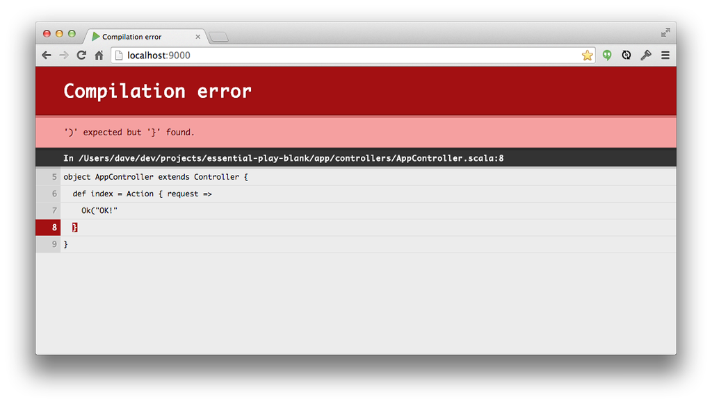

While this behaviour is useful, we should be aware of two drawbacks:

1. The web page only reports the *first* error from the SBT console. A single typo in Scala code can create several compiler errors, so we often have to look at the complete output from SBT to trace down a bug.
2. When we use `sbt run`, Play only recompiles our code when we refresh the web page. This sometimes slows down development because we have to constantly switch back and forth between editor and browser.

We can write and debug code faster if we use SBT’s *continuous compilation* mode instead of `sbt run`. To start continuous compilation, type `~compile` on the SBT console:

```
[hello-world] $ ~compile
[success] Total time: 0 s, completed 11-Oct-2014 11:46:28
1. Waiting for source changes... (press enter to interrupt)
```

In continuous compilation mode, SBT recompiles our code every time we change a file. However, we have to go back to `sbt run` to see the changes in a browser.

### 2.6.2 Runtime Errors

If our code compiles but fails at runtime, we get a similar error page that points to the source of the exception. The exception is reported on the SBT console as well as on the page:

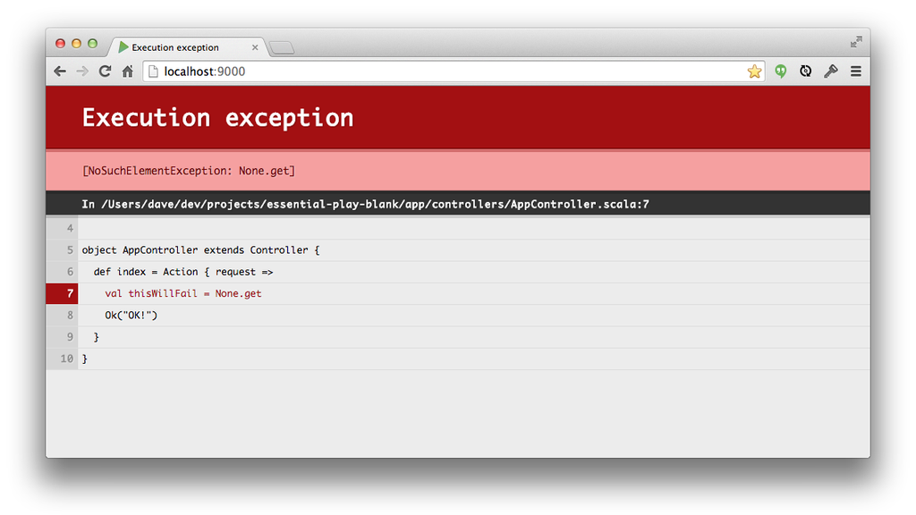

### 2.6.3 Routing Errors

Play generates a 404 page if it can’t find an appropriate route for an incoming request. This error *doesn’t* appear on the console:

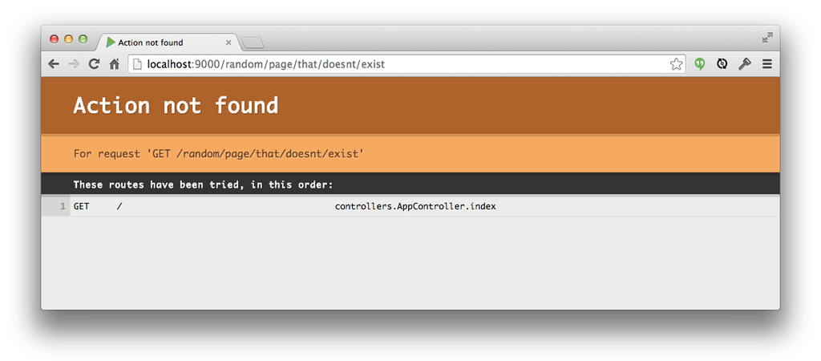

If Play finds a route but can’t parse the parameters from the path and query string, it issues a similar-looking 400 response:

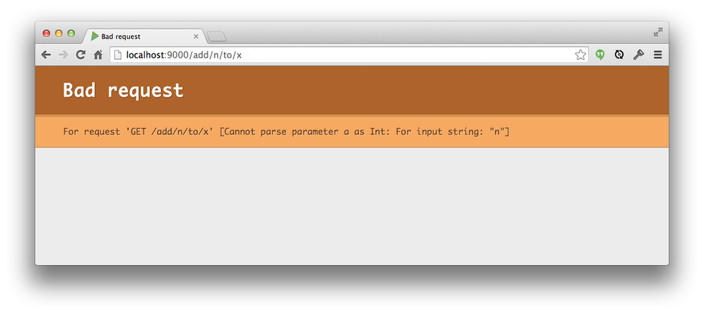

### 2.6.4 Take Home Points

Play gives us nice error messages for compile errors and exceptions during development. We get a default 404 and 400 pages for routing errors, and a default 500 page for compile errors and exceptions at runtime.

These error messages are useful during development, but we should remember to disable it before we put code into production. We will see this next chapter when we create our own HTML and learn how to handle form data.

## 2.7 Extended Exercise: Chat Room Part 1

In addition to the small exercises sprinkled throughout this book, at the end of each chapter we will revisit an ongoing exercise to build a larger application consisting of several components.

We will design this application using a set of mechanical design principles that will allow us to extend it over the course of the book. We will add a web interface in the next chapter, a REST API in the chapter after that, and in the final content chapter we will separate the application into microservices and distribute them across different servers.

### 2.7.1 Application Structure

Our application is a simple internet chat room that can be split into two sets of services:

- *Chat services* control the posting and display of messages in our chat room;
- *Authentication services* allow registered users to log in and out and check their current identity.

Each service can be split into two layers:

- a *service layer*, implemented as pure Scala code with no knowledge of its environment;
- a *controller layer* that maps concepts from the service layer to/from HTTP.

These two divisions can be illustrated as follows, with services as vertical cross-sections of the app, layers as horizontal cross-sections, and four main singleton objects implementing the functionality:

[figure not shown]

Basic structure of the chat application

The methods in `ChatService` and `AuthService` are implemented in a message-passing style, with one input message and one output message each. Specifying the arguments as a single input message will be useful in future chapters for defining mappings to and from HTTP data types such as HTML, form data, and JSON objects.

The messages themselves are implemented in `ChatServiceMessages` and `AuthServiceMessages`. Some of the messages, notably the `Response` messages, have several subtypes. For example a `LoginResponse` may be a `LoginSuccess`, a `UserNotFound`, or a `PasswordIncorrect`.

The controller layer sits between the service layer and the network, translating strongly typed Scala data to weakly typed HTTP data. In a production application there may be multiple controllers for each service: one for a web interface, one for a REST API, and so on. In this exercise we have a single set of controllers implemented using a simple plain text protocol because we don’t yet know how to handle HTML pages or form data:

- most request data is specified in the URL;
- authentication tokens are submitted using cookies;
- all response data is returned in plain text.

Note that `Service` objects don’t talk to one another directly. This is a deliberate design decision to support our eventual aim of distributing the application as a set of microservices. We run all communication through the `Controllers`, reducing the number of files we need to touch to reimplement the internal communcations within the applcation.

### 2.7.2 Completing the Exercise

You have two tasks in the exercise:

1. implement the missing methods in `AuthService` and `ChatService`;
2. implement the missing actions in `AuthController` and `ChatController`.

We have set up routes for you in `conf/routes`. We have also set up unit tests for the services and controllers to help you check your code:

- `controllers.ChatControllerSpec`
- `controllers.AuthControllerSpec`
- `services.ChatServiceSpec`
- `services.AuthServiceSpec`

*Test Driven Development*

As with previous exercises we recommend you proceed by writing code in small chunks. Start with the `Services` files. Concentrate on one file at a time and run the tests to check your work.

You can run the tests for a single class using the `testOnly` command in SBT. Use it in watch mode to get fast turnaround as you work:

```bash
[app] $ ~testOnly services.ChatServiceSpec
```

### 2.7.3 Chat Services

In lieu of using an actual database, `ChatService` maintains an in-memory data store of messages. An immutable `Vector` is a good data type for our purposes because of its efficient iteration and append operations.

The three methods of `ChatService` perform simple operations on the store. They don’t do any authentication checks—we leave these up to `ChatController`:

The `clear` method resets `postedMessages` to an empty `Vector`:

```scala
def clear(): Unit =
  postedMessages = Vector[Message]()
```

The `messages` method returns `postedMessages`. We don’t need to worry about exposing a direct reference to the `Vector` because it is immutable:

```scala
def messages: Seq[Message] =
  postedMessages
```

The `chat` method creates a new `Message`, appends it to the data store, and returns it:

```scala
def chat(author: String, text: String): Message = {
  val message = Message(author, text)
  postedMessages = postedMessages :+ message
  message
}
```

### 2.7.4 Auth Services

Our substitute for a database in `AuthService` consists of two in-memory `Maps`:

- `passwords` stores `Usernames` to `Passwords` for all registered users (there is no option to register for a new account);
- `sessions` stores `SessionIds` and `Usernames` for all *currently authenticated* users.

The `Username`, `Password`, and `SessionId` types are all aliases for `String`. The offer no type safety but they do make the intent clearer in the code. We could easily replace the aliases with value classes if we desired extra type safety.

The `login`, `logout` and `whoami` methods primarily operate on `sessions`.

`login` is the most complex method. It checks the credentials in the `LoginRequest` and returns a `LoginSuccess`, `PasswordIncorrect`, or `UserNotFound` response as appropriate. If the user is successfully logged in, the method creates a `SessionId` and caches it in `sessions` before returning it:

```scala
def login(request: LoginRequest): LoginResponse = {
  passwords.get(request.username) match {
    case Some(password) if password == request.password =>
      val sessionId = generateSessionId
      sessions += (sessionId -> request.username)
      LoginSuccess(sessionId)

    case Some(user) => PasswordIncorrect(request.username)
    case None       => UserNotFound(request.username)
  }
}

def generateSessionId: String =
  java.util.UUID.randomUUID.toString
```

`logout` is much simpler because we always expect it to succeed. If the client passes us a valid `SessionId`, we remove it from `sessions`. Otherwise we simply do nothing:

```scala
def logout(sessionId: SessionId): Unit =
  sessions -= sessionId
```

Finally, `whoami` searches for a `SessionId` in `sessions` and responds with a `Credentials` or `SessionNotFound` object as appropriate:

```scala
def whoami(sessionId: SessionId): WhoamiResponse =
  sessions.get(sessionId) match {
    case Some(username) => Credentials(sessionId, username)
    case None           => SessionNotFound(sessionId)
  }
```

### 2.7.5 Controllers

`ChatController` wraps each method from `ChatService` with a method that does two jobs: translate requests and responses to and from HTTP primitives, and authenticate each request from the client.

The first thing to do when handling any `Request` is to check whether the user has authenticated with `AuthController`. We do this using a help method that extracts a `SessionId` from a cookie, checks it against `AuthService`, and passes the extracted `Credentials` to a success function:

```scala
def withAuthenticatedUser ↩
    (request: Request[AnyContent]) ↩
    (func: Credentials => Result): Result =
  request.sessionCookieId match {
    case Some(sessionId) =>
      AuthService.whoami(sessionId) match {
        case res: Credentials     => func(res)
        case res: SessionNotFound => BadRequest("Not logged in!")
      }
    case None => BadRequest("Not logged in!")
  }
```

With the bulk of the work done, the `index` and `submitMessage` methods are trivial to implement:

```scala
def index = Action { request =>
  withAuthenticatedUser(request) { creds =>
    Ok(ChatService.messages.mkString("\n"))
  }
}

def submitMessage(text: String) = Action { request =>
  withAuthenticatedUser(request) { creds =>
    ChatService.chat(creds.username, text)
    Redirect(routes.ChatController.index)
  }
}
```

`AuthController` is much simpler than `ChatController` because we have only chosen to implement an interface to the `login` method (we’ll implement more methods in future chapters). The `Action` here is simply mapping back and forth between HTTP data and Scala messages:

```scala
def login(username: Username, password: Password) =
  Action { request =>
    AuthService.login(LoginRequest(username, password)) match {
      case res: LoginSuccess =>
        Ok("Logged in!").withSessionCookie(res.sessionId)

      case res: UserNotFound =>
        BadRequest("User not found or password incorrect")

      case res: PasswordIncorrect =>
        BadRequest("User not found or password incorrect")
    }
  }
```

### 2.7.6 Exercise Summary

In this extended exercise we have implemented an application using a simple service-oriented architecture. We have made a clean split between *service level* code written in 100% strongly typed Scala, and *controller level* code to mediate between services and the network.

This two-way split of services and layers is useful for a number of reasons. It allows us to implement additional controllers on top of the same services, paving the way towards the eventual development of a REST API. It also forces us to think of chat and authentication as separate parts of our application, paving the way towards distribution as microservices.

APIs and microservices are to be delayed until later in this book, however. We will revisit the chat application at the end of the next chapter, armed with a knowledge of HTML and web form processing and ready to create a full web interface for our application!

# 3 HTML and Forms

In the last chapter we saw how to receive HTTP requests and send responses. However, we dealt exclusively with content of type `text/plain`. In this chapter we will generate HTML content using Play’s templating language, *Twirl*. We will also learn how to create HTML forms and parse and validate submitted form data.

## 3.1 Twirl Templates

Play uses a templating language called *Twirl* to generate HTML. Twirl templates look similar to PHP, ERB, or JSP code, comprising HTML content and embedded Scala expressions. Templates are compiled to function objects that can be called directly from regular Scala code. In this section we will look at the Twirl syntax and compilation process.

### 3.1.1 A First Template

Twirl templates resemble plain HTML with embedded Scala-like dynamic expressions:

```html
<!-- In app/views/helloWorld.scala.html -->
@(name: String)

<html>
  <head>
    <title>Hello @name</title>
  </head>

  <body>
    <p>Hello there, @name.toUpperCase!</p>
  </body>
</html>
```

The first line of the template describes its *parameters*. The format is an `@` sign followed by one or more Scala parameter lists. The rest of the template consists of HTML content. The syntax of the dynamic expressions is based on Scala code with some Twirl-specific tweaks. We’ll see more of this syntax later on.

Templates are compiled to Scala functions—objects with `apply` methods that accept the parameters declared in the template and return instances of [`play.twirl.api.Html`](https://github.com/playframework/twirl/blob/master/api/src/main/scala/play/twirl/api/Formats.scala):

```scala
package views.html

import play.twirl.api.Html

object helloWorld {
  def apply(name: String): Html = {
    // ...
  }
}
```

`Html` objects are lightweight wrappers for content generated by the template. If we pass an `Html` value to `Result` constructor, Play automatically generates a `Result` of `Content-Type: text/html`:

```scala
def index = Action { request =>
  Ok(views.html.helloWorld("Dave"))
}
```

### 3.1.2 File Names and Compiled Names

We place templates in the `app/views` folder and give them `.scala.html` filename extensions. Their compiled forms are named based on our filenames and placed in the `views.html` package. Here are some examples:

Template paths and their corresponding class names

| Template file name | Scala object name |
| --- | --- |
| `views/helloWorld.scala.html` | `views.html.helloWorld` |
| `views/user/loginForm.scala.html` | `views.html.user.loginForm` |
| `views/foo/bar/baz.scala.html` | `views.html.foo.bar.baz` |

*Non-HTML Templates*

Twirl templates can also be used to generate XML, Javascript, and plain text responses. The folders, packages, and return types vary, but otherwise these templates are identical to the HTML templates discussed here:

Template conventions for different types of content

[output not shown]

### 3.1.3 Parameters and Expressions

Twirl templates can have any number of parameters of arbitrary types. They also support features such as default parameter values, multiple parameter lists, and implicit parameter lists:

```html
<!-- user.scala.html -->
@(user: User, showEmail: Boolean = true)(implicit obfs: EmailObfuscator)

<ul>
  <li>@user.name</li>
  @if(showEmail) {
    <li>@obfs(user.email)</li>
  }
</ul>
```

The template body is compiled to a single Scala expression that appends all the static and dynamic parts to a single `Html` object. Twirl uses runtime pattern matching to convert embedded expressions to HTML. Expressions are escaped to prevent malicious code injection.

Twirl embedded expression syntax is inspired by Scala syntax. Here is a brief synopsis—for more information see Play’s [documentation on template syntax](https://www.playframework.com/documentation/2.3.x/ScalaTemplates).

#### 3.1.3.1 Simple Expressions

Dynamic expressions are prefixed using the `@` character. We don’t need to indicate the end of an expression—Twirl attempts to automatically work out where the Scala code ends and HTML begins:

```html
<p>Hello, @"Dave".toUpperCase!</p>
```

```html
<p>Hello, DAVE!</p>
```

Simple values such as `Strings`, `Ints` and `Booleans` yield representative text:

```html
<p>@(1 + 1) == @2 is @(1 + 1 == 2)!</p>
```

```html
<p>1 + 1 == 2 is true!</p>
```

`Seqs`, `Arrays` and Java collections yield content for every item:

```html
<p>@List("foo", "bar", "baz")</p>
```

```html
<p>foobarbaz</p>
```

`Optional` values yield text content when full and no content when empty:

```html
<p>@Some(0).filter(_ == 0)</p>
<p>@Some(1).filter(_ == 0)</p>
```

```html
<p>0</p>
<p></p>
```

Finally, `Unit` expressions yield no content:

```html
<p>@println("Hi!")</p>
```

```html
<p></p>
```

#### 3.1.3.2 Wrapped Expressions

Twirl occasionally has difficulty determining where dynamic code ends and static content begins. If this is a problem we can use parentheses or braces to delimit the dynamic content:

```html
<p>The first answer is @(1 + 2).</p>

<p>The second answer is @{
  val a = 3
  val b = 4
  a + b
}.</p>
```

```html
<p>The first answer is 3.</p>

<p>The second answer is 7.</p>
```

#### 3.1.3.3 Method Calls

Method calls can be written as usual. Twirl treats parameters between parentheses as Scala:

```html
<p>The maximum is @math.max(1, 2, 3).</p>
```

```html
<p>The maximum is 3.</p>
```

Methods of one parameter can be called using braces instead. Twirl parses the parameter between the braces as HTML:

```html
<ul>
  @(1 to 3).map { item =>
    <li>Item @item</li>
  }
</ul>
```

```html
<ul>
  <li>Item 1</li>
  <li>Item 2</li>
  <li>Item 3</li>
</ul>
```

#### 3.1.3.4 Conditionals

If we delimit the true and false arms using braces, Twirl treats them as HTML. Otherwise they are treated as Scala code:

```html
<p>
  @if(1 > 2) {
    <em>Help! All is wrong!</em>
  } else {
    <em>Phew! All is good.</em>
  }
</p>
```

```html
<p>
  <em>Phew! All is good.</em>
</p>
```

If we omit the false arm of a Scala conditional, it evaluates to `Unit`. Twirl renders this as empty content:

```html
<p>
  Everything is
  @if(false) { NOT } ok.
</p>
```

```html
<p>
  Eerything is
   ok.
</p>
```

#### 3.1.3.5 Match Expressions

If we wrap the right-hand-sides of case clauses in braces, Twirl treats them as HTML content. Otherwise they are treated as Scala code:

```html
<p>
  @List("foo", "bar", "baz") match {
    case Nil =>
      "the list is empty"

    case a :: b => {
      <em>
        the list contains @a,
        and @(b.lenth) other items
      </em>
    }
  }
</p>
```

```html
<p>
  <em>
    the list contains foo,
    and 2 other items
  </em>
</p>
```

#### 3.1.3.6 For-Comprehensions

For-comprehensions are supported without the `yield` keyword, which is implicitly assumed in Twirl syntax:

```html
<ul>
  @for(item <- 1 to 3) {
    <li>Item @item</li>
  }
</ul>
```

```html
<ul>
  <li>Item 1</li>
  <li>Item 2</li>
  <li>Item 3</li>
</ul>
```

#### 3.1.3.7 Pre-Defined Helpers

Twirl provides a `defining` method as a means of aliasing complex Scala expressions as single identifiers:

```html
<p>
  @defining(1 + 2 + 3 + 4) { sum =>
    The answer is @sum.
  }
</p>
```

```html
<p>
  The answer is 10.
</p>
```

Play also provides a variety of pre-defined templates in the [`views.html.helper`](https://www.playframework.com/documentation/2.3.x/api/scala/index.html#views.html.helper.package) package. We will discuss some of these in the next section.

### 3.1.4 Nesting Templates

Because Twirl templates compile to Scala functions, we can call one template from another. We can also pass `Html` content from one template to another to create wrapper-style constructions:

```html
<!-- app/views/main.scala.html -->
@hello("Dave")

<!-- app/views/hello.scala.html -->
@(name: String)

@layout("Hello " + name) {
  <p>Hello there, @name.</p>
}

<!-- app/views/layout.scala.html -->
@(title: String)(body: Html)

<html>
  <head>
    <title>@title</title>
  </head>
  <body>
    @body
  </body>
</html>
```

```html
<html>
  <head>
    <title>Hello Dave</title>
  </head>
  <body>
    <p>Hello there, Dave.</p>
  </body>
</html>
```

### 3.1.5 Take Home Points

We create HTML in Play using a templating language called *Twirl*.

We place Twirl templates in the `app/views` folder and give them the extension `.scala.html`.

Templates are compiled to singleton Scala functions in the `views.html` package.

Template functions accept whatever parameters we define and return instances of [`play.twirl.api.Html`](https://github.com/playframework/twirl/blob/master/api/src/main/scala/play/twirl/api/Formats.scala). Play understands how to serialize `Html` objects as content within `Results`. It even sets the `Content-Type` for us.

### 3.1.6 Exercise: Much Todo About Nothing

The `chapter3-todo-view` directory in the exercises contains an unfinished Play application for managing a todo list.

Complete the view part of this application by adding templates for the todo list and items. Your solution should:

- render a `<ul>` element for the list and `<li>` elements for each todo item;
- render the item label and an HTML checkbox for each item;
- render the `item.id` as the `id` attribute of the `<li>`.

Be sure to make a clean separation between HTML boilerplate (the elements) and the content of the todo list page. Create two templates:

- `pageLayout` accepts two parameters: a `String` title and `Html` content. It wraps them in `<html>`, `<head>`, and `<body>` elements.
- `todoList` accepts a single parameter of type `TodoList`. It renders the `<ul>` and `<li>` elements described above and delegates the generic boilerplate to `pageLayout`.

The templates go in the `app/views` directory in separate files: `app/views/pageLayout.scala.html` and `app/views/todoList.scala.html`.

Here’s a minimal version of `pageLayout.scala.html`:

```scala
@(title: String)(content: => Html)

<!DOCTYPE html>
<html>
<head>
  <title>@title</title>
</head>
<body>
  <h1>@title</h1>
  @content
</body>
</html>
```

Note the two parameter lists in the template header. We’ve written the parameters like this to create a nice syntax for using the template. We can pass the `title` parameter as a regular Scala expression in parentheses and the `content` as an HTML expression in braces:

```scala
@pageLayout("My Page") {
  <p>This is my page!</p>
}
```

Here’s a minimal version of `todoList.scala.html`:

```scala
@(todoList: TodoList)

@pageLayout("Todo List") {
  <ul class="todo-list">
  @for(item <- todoList.items) {
    <li id="@item.id" class="todo-item">
      <label>
        <input type="checkbox" @if(item.complete) { checked }>
        @item.label
      </label>
    </li>
  }
  </ul>
}
```

The template accepts a single `TodoList` parameter and uses a for comprehension to iterate through the list. Note that Twirl’s `for` syntax doesn’t require us to write `yield` to produce results.

Finally, the template uses `if` to decide whether to write a `checked` attribute on the checkbox. We’ve used an `if` without an `else`, which omits the attribute if the todo item is incomplete.

## 3.2 Form Handling

In the previous section we saw how to send HTML data to web site users using Twirl templates. In this section we will look at receiving HTML form data from users.

Play’s form handling library is based on objects of type [`play.api.data.Form`](https://www.playframework.com/documentation/2.3.x/api/scala/index.html#play.api.data.Form). `Forms` are metadata objects that represent a combination of mapping information and form data. They allow us to perform four important operations:

1. parse incoming request data to create typed values;
2. validate the incoming data, allowing us to recover if the user made a mistake;
3. generate HTML forms and inputs using stored data (and error messages from failed validations);
4. populate generated HTML with values taken from data values.

We’ll start by looking at parsing and validation.

### 3.2.1 *Forms* and *Mappings*

`Forms` define mappings between form data and typed *domain values* from our domain model. Here’s an example:

```scala
case class Todo(name: String, priority: Int, complete: Boolean)
```

Play represents incoming form data as a `Map[String, String]`. The `Form` object helps us convert the incoming form data to a `Todo` value. We create a `Form` as follows:

```scala
import play.api.data._
import play.api.data.Forms._

val todoForm = Form(mapping(
  "name"      -> text,
  "priority"  -> number,
  "complete"  -> boolean
)(Todo.apply)(Todo.unapply))
```

Let’s break this code down into its component parts. The methods `text`, `number`, and `boolean` come from [`play.api.data.Forms`](https://www.playframework.com/documentation/2.3.x/api/scala/index.html#play.api.data.Forms$). They create field `Mappings` between `Strings` and the relevant type for each field of `Todo`. We could declare each mapping separately as follows:

```scala
val nameMapping:     Mapping[String]  = text
val priorityMapping: Mapping[Int]     = number
val tunaMapping:     Mapping[Boolean] = boolean
```

The `mapping` method, also from `Forms`, associates a name with each field and declares how to combine them together into an overall data value:

```scala
val todoMapping: Mapping[Todo] = mapping(
  "name"     -> text,
  "priority" -> number,
  "complete" -> boolean
)(Todo.apply)(Todo.unapply)
```

The final `Mapping` can be used to create a `Form` of the relevant type:

```scala
val todoForm: Form[Todo] = Form(todoMapping)
```

We typically use the `Form` object and not the `Mappings` in application code, so we can write all of this as a single definition. This brings us back to the example we started with:

```scala
val todoForm = Form(mapping(
  "name"      -> text,
  "priority"  -> number,
  "complete"  -> boolean
)(Todo.apply)(Todo.unapply))
```

### 3.2.2 Handling Form Data

A `Form` is a combination of the mappings we defined above and a set of data values. Our initial `todoForm` is empty, but we can combine it with incoming request data to create a *populated form*. This process is called *binding* the request:

```scala
val populatedForm = todoForm.bindFromRequest()(request)
```

*Implicit requests*

The `request` parameter of `bindFromRequest` is actually `implicit`. We can omit it if we declare the parameter to our `Action` `implicit` as well:

```scala
def submitForm = Action { implicit request =>
  val populatedForm = todoForm.bindFromRequest()
  // ... do something with `populatedForm` ...
}
```

`bindFromRequest` creates a new `Form` and populates it with data from `request`. Besides caching the data in its raw form, `Form` and attempts to parse and validate it to produce a `Todo` item. The result is stored along-side the original request data in the new `populatedForm`. Binding is a a non-destructive operation—`todoForm` is left untouched by the process.

There are two possible outcomes of binding a request:

- the request data is successfully parsed and validated, creating a new `Todo` object;
- the request data cannot be interpreted, resulting in a set of error messages to show the user.

`Form` stores the end result of the binding operation regardless of whether it succeeds or fails. We can extract the result using the `fold` method on `Form`, which accepts two function parameters to handle each case. `fold` returns the result of calling the relevant function:

```scala
package play.api.data

trait Form[A] {
  def fold[B](hasErrors: Form[A] => B, success: A => B): B =
    // ...
}
```

It is common to call `fold` supplying failure and success functions that return `Results`. On failure we send the `<form>` back to the user with a set of error messages; on success we redirect the user to an appropriate page:

```scala
def submitTodoForm = Action { request =>
  todoForm.bindFromRequest()(request).fold(
    // Failure function:
    (formContainingErrors: Form[Todo]) => {
      // Show the user a completed form with error messages:
      BadRequest(views.html.todoFormTemplate(formContainingErrors))
    },
    // Success function:
    (todo: Todo) => {
      // Save `todo` to a database and redirect:
      Redirect("/")
    }
  )
}
```

### 3.2.3 Form Validation

Binding a request attempts to parse the incoming data, but it can also *validate* once parsed. The form API contains methods for creating validation constraints and adding them to mappings. `Form.fold` invokes our failure callback if any of our constraints are not satisfied:

```scala
import play.api.data.validation.Constraints.min

val todoForm: Form[Todo] = Form(mapping(
  "name"      -> nonEmptyText,                        // cannot be ""
  "priority"  -> number.verifying(min(1) and max(3)), // must be 1 to 3
  "complete"  -> boolean                              // no validation
)(Todo.apply)(Todo.unapply))
```

Play provides lots of options for parsing and validating, including adding multiple and custom validation constraints to fields and mapping hierarchical and sequential data. See the [documentation for Forms](https://www.playframework.com/documentation/2.3.x/ScalaForms), the Scaladoc for [`play.api.data.Forms`](https://www.playframework.com/documentation/2.3.x/api/scala/index.html#play.api.data.Forms$), and the Scaladoc for [`play.api.data.validation.Constraints`](https://www.playframework.com/documentation/2.3.x/api/scala/index.html#play.api.data.validation.Constraints$) for more information.

### 3.2.4 Take Home Points

In this section we saw how to create `Form` objects and use them to parse and validate incoming form data.

We create `Forms` using `Mappings` defined using methods from [`play.api.data.Forms`](https://www.playframework.com/documentation/2.3.x/api/scala/index.html#play.api.data.Forms$).

We extract data from requests using the `bindFromRequest` method of `Form`. Binding may succeed or fail, so we specify behaviours in either case using the `fold` method.

In the next section we will see how to use `Forms` to generate HTML `<form>` and `<input>` tags, pre-populate inputs with text taken from typed Scala data, and report error messages back to the user.

## 3.3 Generating Form HTML

In the previous section we saw how to use `Forms` to parse incoming request data from the browser. `Forms` also allow us to generate `<form>` tags that help the browser send data to us in the correct format. In this section we’ll use `Forms` to generate `<form>` and `<input>` elements and populate them with data and validation errors:

### 3.3.1 Forms and Inputs

Play provides several built-in templates in the [`views.html.helper`](https://www.playframework.com/documentation/2.3.x/api/scala/index.html#views.html.helper.package) package for generating `<form>` and `<input>` elements:

```scala
@(todoForm: Form[Todo])

@helper.form(action = routes.TodoController.submitTodoForm) {
  @helper.checkbox(todoForm("complete"))
  @helper.inputText(todoForm("name"))
  @helper.inputText(todoForm("priority"))
  <button type="submit">OK</button>
}
```

If we place this file in `app/views/todoFormTemplate.scala.html`, we can invoke it as follows:

```scala
Ok(views.html.todoFormTemplate(todoForm))
```

The generated HTML contains a `<form>` element and an `<input>` and `<label>` for each field, together with hints on which fields are numeric and boolean:

```html
<form action="/todo" method="POST">
  <dl id="name_field">
    <dt><label for="name">name</label></dt>
    <dd><input type="text" id="name"
               name="name" value="" /></dd>
  </dl>
  <dl id="priority_field">
    <dt><label for="priority">priority</label></dt>
    <dd><input type="text" id="priority"
               name="priority" value="" /></dd>
    <dd class="info">Numeric</dd>
  </dl>
  <dl id="complete_field">
    <dt><label for="complete">complete</label></dt>
    <dd><input type="checkbox" id="complete"
               name="complete" value="true" /></dd>
    <dd class="info">format.boolean</dd>
  </dl>
  <button type="submit">OK</button>
</form>
```

*Internationalization*

Notice the text `"format.boolean"` in the generated HTML. This is an uninternationalized message that has crept through due to a missing value in Play’s default string tables. We can fix the broken message by providing our own [internationalization](https://www.playframework.com/documentation/2.3.x/ScalaI18N) for our application. See the linked documentation for details.

### 3.3.2 Pre-Filling Forms

Sometimes we want to pre-fill a `Form` with data taken from a database. We can do this with the `fill` method, which returns a new `Form` filled with input values:

```scala
val populatedForm = todoForm.fill(Todo("Start Essential Scala", 1, true))
val populatedHtml = views.html.todoFormTemplate(populatedForm)
```

The `<inputs>` in the `populatedHtml` here have their `value` and `checked` attributes set to appropriate starting values:

```html
<form action="/todo" method="POST">
  <dl id="name_field">
    <dt><label for="name">name</label></dt>
    <dd><input type="text" id="name"
               name="name" value="Start Essential Scala" /></dd>
  </dl>
  <dl id="priority_field">
    <dt><label for="priority">priority</label></dt>
    <dd><input type="text" id="priority"
               name="priority" value="1" /></dd>
    <dd class="info">Numeric</dd>
  </dl>
  <dl id="complete_field">
    <dt><label for="complete">complete</label></dt>
    <dd><input type="checkbox" id="complete"
               name="complete" value="true" checked="checked" /></dd>
    <dd class="info">format.boolean</dd>
  </dl>
  <button type="submit">OK</button>
</form>
```

### 3.3.3 Displaying Validation Errors

If we fail to bind a request in our `Action`, Play calls the failure argument in our call to `Form.fold`. The argument to our failure function is a `Form` containing a complete set of validation error messages. If we pass the `Form` with errors to our form template, Play will add the error messages to the generated HTML:

```scala
val badData = Map(
  "name"     -> "Todo",
  "priority" -> "unknown",
  "complete" -> "maybe"
)

todoForm.bind(badData).fold(
  (errorForm: Form[Todo]) => {
    BadRequest(views.html.todoFormTemplate(errorForm))
  },
  (todo: Todo) => {
    Redirect("/")
  }
)
```

The resulting HTML contains extra `<dd class="error">` tags describing the errors:

```html
<form action="/todo" method="POST">
  <dl class=" " id="name_field">
    <dt><label for="name">Todo name</label></dt>
    <dd><input type="text" id="name"
               name="name" value="Todo" /></dd>
  </dl>
  <dl class=" error" id="priority_field">
    <dt><label for="priority">priority</label></dt>
    <dd><input type="text" id="priority"
               name="priority" value="unknown" /></dd>
    <dd class="error">Numeric value expected</dd>
  </dl>
  <dl class=" error" id="complete_field">
    <dt><label for="complete">complete</label></dt>
    <dd><input type="checkbox" id="complete"
               name="complete" value="true" /></dd>
    <dd class="error">error.boolean</dd>
    <dd class="info">format.boolean</dd>
  </dl>
  <button type="submit">OK</button>
</form>
```

### 3.3.4 Customising the HTML

We can tweak the HTML for our inputs by passing extra arguments to `inputText` and `checkbox`:

*Twirl code:*

```scala
@helper.inputText(
  todoForm("name"),
  'id     -> "todoname",
  '_label -> "Todo name",
  '_help  -> "Enter the name of your todo"
)
```

*Resulting HTML:*

```scala
<dl id="todoname_field">
  <dt><label for="todoname">Todo name</label></dt>
  <dd><input type="text" id="todoname" name="name" value=""></dd>
  <dd class="info">Enter the name of your todo</dd>
</dl>
```

The extra parameters are keyword/value pairs of type `(Symbol, String)`. Most keywords add or replace attributes on the `<input>` element. Certain special keywords starting with an `_` change the HTML in other ways:

- `'_label` customises the text in the `<label>` element;
- `'_help` adds a line of help text to the element;
- `'_id` alters the `id` attribute of the `<dl>` tag (as opposed to the `<input>`).

See the Play [documentation on field constructors](https://www.playframework.com/documentation/2.3.x/ScalaCustomFieldConstructors) for a complete list of special keywords.

*Custom Field Constructors*

Sometimes small tweaks to the HTML aren’t enough. We can make comprehensive changes to the HTML structure by specifying a *field constructor* in our template. See the [documentation on field constructors](https://www.playframework.com/documentation/2.3.x/ScalaCustomFieldConstructors) for more information.

[This StackOverflow post](http://stackoverflow.com/questions/10436815/how-to-use-twitter-bootstrap-2-with-play-framework-2-x) contains information on using a custom field constructor to generate [Twitter Bootstrap](http://getbootstrap.com) compatible form HTML.

### 3.3.5 Take Home Points

`Forms` can be used to generate HTML as well as parse request data.

There are numerous helpers in the [`views.html.helper`](https://www.playframework.com/documentation/2.3.x/api/scala/index.html#views.html.helper.package) package that we can use in our templates, including the following:

- [`views.html.helper.form`](https://www.playframework.com/documentation/2.3.x/api/scala/index.html#views.html.helper.form$) generates `<form>` elements from `Form` objects;
- [`views.html.helper.inputText`](https://www.playframework.com/documentation/2.3.x/api/scala/index.html#views.html.helper.inputText$) generates `<input type="text">` elements for specific form fields;
- [`views.html.helper.checkbox`](https://www.playframework.com/documentation/2.3.x/api/scala/index.html#views.html.helper.checkbox$) generates `<input type="checkbox">` elements for specific form fields.

The HTML we generate contains values and error messages as well as basic form structure. We can use this to generate pre-populated forms or feedback to user error.

We can tweak the generated HTML by passing extra parameters to helpers such as `inputText` and `checkbox`, or make broad sweeping changes using a custom field constructor.

### 3.3.6 Exercise: A Simple Formality

The `chapter3-todo-form` directory in the exercises contains an application based on the solution to the previous exercise, *Much Todo About Nothing*.

Modify this application to add a form for creating new todo items. Place the form under the current todo list and allow the user to label the new todo and optionally imediately mark it complete.

Start by defining a `Form[Todo]`. Either place the form in `TodoController` or create a `TodoFormHelpers` trait in a similar vein to `TodoDataHelpers`. Note that the `Todo` class in the exercise is different from the example `Todo` class used in examples in this chapter. You will have to update the example field mapping accordingly.

Once your `Form` is compiling, turn your attention to the page template. Pass a `Form` as a parameter and render the relevant HTML using the helper methods described above. Use the pre-defined `TodoController.submitTodoForm` action to handle the form submission.

Finally, fill out the definition of `TodoController.submitTodoForm`. Extract the form data from the request, run the validation, and respond appropriately. If the form is valid, create a new `Todo`, add it to `todoList`, and redirect to `TodoController.index`. Otherwise return the form to the user showing any validation errors encountered.

The minimal `Form` definition provides mappings for each of the three fields: `id`, `label`, and `complete`. We use Play’s `nonEmptyText` helper as a shortcut for `text.verifying(nonEmpty)`:

```scala
val todoForm: Form[Todo] = Form(mapping(
  "id"        -> text,
  "label"     -> nonEmptyText,
  "complete"  -> boolean
)(Todo.apply)(Todo.unapply))
```

The model solution goes one step beyond this by defining a custom constraint for the optional UUID-formatted `id` field:

```scala
import scala.util.matching.Regex

val uuidRegex: Regex =
  "(?i:[a-f0-9]{8}-[a-f0-9]{4}-[a-f0-9]{4}-[a-f0-9]{4}-[a-f0-9]{12})".r

val uuidConstraint: Constraint[String] =
  pattern(regex = uuidRegex, name = "UUID", error = "error.uuid")

val todoForm: Form[Todo] = Form(mapping(
  "id"        -> optional(text.verifying(uuidConstraint)),
  "label"     -> nonEmptyText,
  "complete"  -> boolean
)(Todo.apply)(Todo.unapply))
```

If the browser submits a form with a malformed `id`, this constraint will pick it up. The `error.uuid` error code is our own invention—it won’t appear in a human-friendly format in the web page if the constraint is violated, but it is fine for debugging purposes.

Here is a minimal template to render this form in HTML. We’ve factored the code out into its own file, `todoForm.scala.html`:

```html
@(form: Form[models.Todo])

@helper.form(action = routes.TodoController.submitTodoForm, 'class -> "todo-form") {
  @helper.checkbox(
    form("complete"),
    '_class -> "todo-complete",
    '_label -> "",
    '_help -> ""
  )

  @helper.inputText(
    form("label"),
    '_class -> "todo-label",
    '_label -> "",
    '_help -> "",
    'placeholder -> "Enter a new todo"
  )

  <button type="submit">Create</button>
}
```

We don’t need to add the `id` field to the HTML because new `Todos` always have an `id` of `None`. If we wanted to edit `Todos` as well as create them we’d have to add a hidden field as follows:

```html
<input type="hidden" name="id" value="@form("id").value">
```

We need to update `todoList.scala.html` and `TodoController.renderTodoList` to pass the `Form` through. Here’s `renderTodoList`:

```scala
def renderTodoList(todoList: TodoList, form: Form[Todo]): Html =
  views.html.todoList(todoList, form)
```

and here’s `todoList.scala.html`:

```html
@(todoList: TodoList, form: Form[models.Todo])

@import models._

@pageLayout("Todo") {
  <h2>My current todos</h2>

  <!-- Render the todo list... -->

  <h2>Add a new todo</h2>

  @todoForm(form)
}
```

With this infrastructure in place we can implement `submitTodoForm`:

```scala
def submitTodoForm = Action { implicit request =>
  todoForm.bindFromRequest().fold(
    hasErrors = { errorForm =>
      BadRequest(renderTodoList(todoList, errorForm))
    },
    success = { todo =>
      todoList = todoList.addOrUpdate(todo)
      Redirect(routes.TodoController.index)
    }
  )
}
```

*Extra Credit Exercise*

If you get the create form working, as an extended exercise you could try modifying the page so that every todo item is editable. You have free reign to decide how to do this—there are a few options available to you:

- You can create separate `Forms` and `Actions` for creating and editing `Todos`. You will have to define custom mappings between the `Forms` and the `Todo` class.
- You can re-use your existing `Form` and `submitTodoForm` for both purposes. You’ll have to update the definition of `submitTodoForm` to examine the `id` field and see if it was submitted.

See the `solutions` branch for a complete model solution using the second of these approaches.

## 3.4 Serving Static Assets

It’s a shame, but we can’t yet implement web sites in 100% Scala (although [some valiant souls](http://www.scala-js.org/) are working on getting us there). There are other resources that need to be bundled with our HTML, including, CSS, Javascript, image assets, and fonts. Play includes a build system called [`sbt-web`](https://github.com/sbt/sbt-web/) help compile and serve non-Scala assets.

### 3.4.1 The *Assets* Controller

Play provides an `Assets` controller for serving static files from the filesystem. This is ideal for images, fonts, CSS, and Javascript files. To configure the controller, simply add the following to the end of your `routes`:

```
GET  /assets/*file  controllers.Assets.at(path="/public", file)
```

Make a directory called `public` in the root directory of your project. The `Assets` controller serves any files in the `public` directory under the `/assets` URL prefix. It also provides reverse routes to calculate the URL of any file given its path relative to `public`—extremely useful when writing page layout templates:

| Local filename | Local URL | Reverse route |
| --- | --- | --- |
| `public/images/cat.jpg` | `/assets/images/cat.jpg` | `@routes.Assets.at("images/cat.jpg")` |
| `public/audio/meow.mp3` | `/assets/audio/meow.mp3` | `@routes.Assets.at("audio/meow.mp3")` |

### 3.4.2 Compiling Assets

Play uses the `sbt-web` build system to provide an extensive and customisable range of build steps for static assets, including:

- RequireJS modules using the sbt-rjs plugin;
- [asset fingerprinting](http://guides.rubyonrails.org/asset_pipeline.html#what-is-fingerprinting-and-why-should-i-care-questionmark) using the sbt-digest plugin;
- compression using the sbt-gzip plugin;
- common Javascript and CSS dependencies via the [WebJars](http://www.webjars.org/) project.

See the [Play documentation on assets](https://www.playframework.com/documentation/2.3.x/Assets) and the [sbt-web web site](https://github.com/sbt/sbt-web/) for more information.